# Project: Wrangle and Analyze Data

- Introduction
- Gathering Data
  - Gather From a File
  - Gather From a URL
  - Gather From an API
- Assesing Data
  - Visual Assessments
  - Programmatic Assessments
- Cleaning Data
- Storing Data
  - Store Data to CSV
  - Store Data to SQLite
- Analyzing and Visualizing Data

## Introduction

> Real-world data rarely comes clean. Using Python and its libraries, will gather data from a variety of sources and in a variety of formats, assess its quality and tidiness, then clean it. This is called data wrangling. will plus showcase them through analyses and visualizations using Python (and its libraries) and/or SQL.

> The dataset that will be wrangling (and analyzing and visualizing) is the tweet archive of Twitter user @dog_rates, also known as WeRateDogs. WeRateDogs is a Twitter account that rates people's dogs with a humorous comment about the dog. These ratings almost always have a denominator of 10. The numerators, though? Almost always greater than 10. 11/10, 12/10, 13/10, etc. Why? Because "they're good dogs Brent." WeRateDogs has over 4 million followers and has received international media coverage.

> WeRateDogs downloaded their Twitter archive and sent it to Udacity via email exclusively for you to use in this project. This archive contains basic tweet data (tweet ID, timestamp, text, etc.) for all 5000+ of their tweets as they stood on August 1, 2017. More on this soon.

### Important Key Points should keep in mind :

- You only want original ratings (no retweets) that have images. Though there are 5000+ tweets in the dataset, not all are dog ratings and some are retweets.
- Assessing and cleaning the entire dataset completely would require a lot of time, and is not necessary to practice and demonstrate your skills in data wrangling. Therefore, the requirements of this project are only to assess and clean at least 8 quality issues and at least 2 tidiness issues in this dataset.
- Cleaning includes merging individual pieces of data according to the rules of tidy data.
- The fact that the rating numerators are greater than the denominators does not need to be cleaned. This unique rating system is a big part of the popularity of WeRateDogs.
- You do not need to gather the tweets beyond August 1st, 2017. You can, but note that you won't be able to gather the image predictions for these tweets since you don't have access to the algorithm used.

```python
import pandas as pd
import tweepy
import requests
import csv
import json
from sqlalchemy import create_engine
import matplotlib.pyplot as plt
%matplotlib inline
```

## Gathering Data

### Gather From a file on hand

```python
Enhanced_twitter_archive = pd.read_csv('twitter-archive-enhanced.csv')
```

```python
Enhanced_twitter_archive
```

|  | tweet_id | in_reply_to_status_id | in_reply_to_user_id | timestamp | source | text | retweeted_status_id | retweeted_status_user_id | retweeted_status_timestamp | expanded_urls | rating_numerator | rating_denominator | name | doggo | floofer | pupper | puppo |
| --- | --- | --- | --- | --- | --- | --- | --- | --- | --- | --- | --- | --- | --- | --- | --- | --- | --- |
| 0 | 892420643555336193 | NaN | NaN | 2017-08-01 16:23:56 +0000 | <a href="http://twitter.com/download/iphone" r... | This is Phineas. He's a mystical boy. Only eve... | NaN | NaN | NaN | https://twitter.com/dog_rates/status/892420643... | 13 | 10 | Phineas | None | None | None | None |
| 1 | 892177421306343426 | NaN | NaN | 2017-08-01 00:17:27 +0000 | <a href="http://twitter.com/download/iphone" r... | This is Tilly. She's just checking pup on you.... | NaN | NaN | NaN | https://twitter.com/dog_rates/status/892177421... | 13 | 10 | Tilly | None | None | None | None |
| 2 | 891815181378084864 | NaN | NaN | 2017-07-31 00:18:03 +0000 | <a href="http://twitter.com/download/iphone" r... | This is Archie. He is a rare Norwegian Pouncin... | NaN | NaN | NaN | https://twitter.com/dog_rates/status/891815181... | 12 | 10 | Archie | None | None | None | None |
| 3 | 891689557279858688 | NaN | NaN | 2017-07-30 15:58:51 +0000 | <a href="http://twitter.com/download/iphone" r... | This is Darla. She commenced a snooze mid meal... | NaN | NaN | NaN | https://twitter.com/dog_rates/status/891689557... | 13 | 10 | Darla | None | None | None | None |
| 4 | 891327558926688256 | NaN | NaN | 2017-07-29 16:00:24 +0000 | <a href="http://twitter.com/download/iphone" r... | This is Franklin. He would like you to stop ca... | NaN | NaN | NaN | https://twitter.com/dog_rates/status/891327558... | 12 | 10 | Franklin | None | None | None | None |
| ... | ... | ... | ... | ... | ... | ... | ... | ... | ... | ... | ... | ... | ... | ... | ... | ... | ... |
| 2351 | 666049248165822465 | NaN | NaN | 2015-11-16 00:24:50 +0000 | <a href="http://twitter.com/download/iphone" r... | Here we have a 1949 1st generation vulpix. Enj... | NaN | NaN | NaN | https://twitter.com/dog_rates/status/666049248... | 5 | 10 | None | None | None | None | None |
| 2352 | 666044226329800704 | NaN | NaN | 2015-11-16 00:04:52 +0000 | <a href="http://twitter.com/download/iphone" r... | This is a purebred Piers Morgan. Loves to Netf... | NaN | NaN | NaN | https://twitter.com/dog_rates/status/666044226... | 6 | 10 | a | None | None | None | None |
| 2353 | 666033412701032449 | NaN | NaN | 2015-11-15 23:21:54 +0000 | <a href="http://twitter.com/download/iphone" r... | Here is a very happy pup. Big fan of well-main... | NaN | NaN | NaN | https://twitter.com/dog_rates/status/666033412... | 9 | 10 | a | None | None | None | None |
| 2354 | 666029285002620928 | NaN | NaN | 2015-11-15 23:05:30 +0000 | <a href="http://twitter.com/download/iphone" r... | This is a western brown Mitsubishi terrier. Up... | NaN | NaN | NaN | https://twitter.com/dog_rates/status/666029285... | 7 | 10 | a | None | None | None | None |
| 2355 | 666020888022790149 | NaN | NaN | 2015-11-15 22:32:08 +0000 | <a href="http://twitter.com/download/iphone" r... | Here we have a Japanese Irish Setter. Lost eye... | NaN | NaN | NaN | https://twitter.com/dog_rates/status/666020888... | 8 | 10 | None | None | None | None | None |

2356 rows × 17 columns

### Gather From a URL Request

```python
response = requests.get('https://d17h27t6h515a5.cloudfront.net/topher/2017/August/599fd2ad_image-predictions/image-predictions.tsv')
decoded_content = response.content.decode('utf-8')
cr = csv.reader(decoded_content.splitlines() , delimiter='\t')
my_list = list(cr)
print(my_list)
```

```
[['tweet_id', 'jpg_url', 'img_num', 'p1', 'p1_conf', 'p1_dog', 'p2', 'p2_conf', 'p2_dog', 'p3', 'p3_conf', 'p3_dog'], ['666020888022790149', 'https://pbs.twimg.com/media/CT4udn0WwAA0aMy.jpg', '1', 'Welsh_springer_spaniel', '0.465074', 'True', 'collie', '0.156665', 'True', 'Shetland_sheepdog', '0.061…
```

```python
# Delete the first line which is the column names
my_list.remove(my_list[0])
```

```python
image_predictions = pd.DataFrame(my_list , columns = ['tweet_id' , 'tjpg_url' , 'timg_num' , 'tp1' , 'tp1_conf' ,'tp1_dog' , 'tp2' , 'tp2_conf' , 'tp2_dog' , 'tp3' , 'tp3_conf' , 'tp3_dog'])
```

```python
image_predictions
```

|  | tweet_id | tjpg_url | timg_num | tp1 | tp1_conf | tp1_dog | tp2 | tp2_conf | tp2_dog | tp3 | tp3_conf | tp3_dog |
| --- | --- | --- | --- | --- | --- | --- | --- | --- | --- | --- | --- | --- |
| 0 | 666020888022790149 | https://pbs.twimg.com/media/CT4udn0WwAA0aMy.jpg | 1 | Welsh_springer_spaniel | 0.465074 | True | collie | 0.156665 | True | Shetland_sheepdog | 0.0614285 | True |
| 1 | 666029285002620928 | https://pbs.twimg.com/media/CT42GRgUYAA5iDo.jpg | 1 | redbone | 0.506826 | True | miniature_pinscher | 0.07419169999999999 | True | Rhodesian_ridgeback | 0.07201 | True |
| 2 | 666033412701032449 | https://pbs.twimg.com/media/CT4521TWwAEvMyu.jpg | 1 | German_shepherd | 0.596461 | True | malinois | 0.13858399999999998 | True | bloodhound | 0.11619700000000001 | True |
| 3 | 666044226329800704 | https://pbs.twimg.com/media/CT5Dr8HUEAA-lEu.jpg | 1 | Rhodesian_ridgeback | 0.408143 | True | redbone | 0.360687 | True | miniature_pinscher | 0.222752 | True |
| 4 | 666049248165822465 | https://pbs.twimg.com/media/CT5IQmsXIAAKY4A.jpg | 1 | miniature_pinscher | 0.560311 | True | Rottweiler | 0.243682 | True | Doberman | 0.154629 | True |
| ... | ... | ... | ... | ... | ... | ... | ... | ... | ... | ... | ... | ... |
| 2070 | 891327558926688256 | https://pbs.twimg.com/media/DF6hr6BUMAAzZgT.jpg | 2 | basset | 0.555712 | True | English_springer | 0.22576999999999997 | True | German_short-haired_pointer | 0.175219 | True |
| 2071 | 891689557279858688 | https://pbs.twimg.com/media/DF_q7IAWsAEuuN8.jpg | 1 | paper_towel | 0.17027799999999998 | False | Labrador_retriever | 0.16808599999999999 | True | spatula | 0.0408359 | False |
| 2072 | 891815181378084864 | https://pbs.twimg.com/media/DGBdLU1WsAANxJ9.jpg | 1 | Chihuahua | 0.716012 | True | malamute | 0.078253 | True | kelpie | 0.0313789 | True |
| 2073 | 892177421306343426 | https://pbs.twimg.com/media/DGGmoV4XsAAUL6n.jpg | 1 | Chihuahua | 0.323581 | True | Pekinese | 0.0906465 | True | papillon | 0.0689569 | True |
| 2074 | 892420643555336193 | https://pbs.twimg.com/media/DGKD1-bXoAAIAUK.jpg | 1 | orange | 0.09704860000000001 | False | bagel | 0.08585110000000001 | False | banana | 0.07611 | False |

2075 rows × 12 columns

```python
image_predictions.info()
```

```
<class 'pandas.core.frame.DataFrame'>
RangeIndex: 2075 entries, 0 to 2074
Data columns (total 12 columns):
 #   Column    Non-Null Count  Dtype
---  ------    --------------  -----
 0   tweet_id  2075 non-null   object
 1   tjpg_url  2075 non-null   object
 2   timg_num  2075 non-null   object
 3   tp1       2075 non-null   object
 4   tp1_conf  2075 non-null   object
 5   tp1_dog   2075 non-null   object
 6   tp2       2075 non-null   object
 7   tp2_conf  2075 non-null   object
 8   tp2_dog   2075 non-null   object
 9   tp3       2075 non-null   object
 10  tp3_conf  2075 non-null   object
 11  tp3_dog   2075 non-null   object
dtypes: object(12)
memory usage: 194.7+ KB
```

- *Data Types is a problem Need to fix later on.*

### Gather From an API

```python
import tweepy
from tweepy import OAuthHandler
import json
from timeit import default_timer as timer

# Query Twitter API for each tweet in the Twitter archive and save JSON in a text file
# These are hidden to comply with Twitter's API terms and conditions
consumer_key = 'HIDDEN'
consumer_secret = 'HIDDEN'
access_token = 'HIDDEN'
access_secret = 'HIDDEN'

auth = OAuthHandler(consumer_key, consumer_secret)
auth.set_access_token(access_token, access_secret)

api = tweepy.API(auth, wait_on_rate_limit=True)

# NOTE TO STUDENT WITH MOBILE VERIFICATION ISSUES:
# df_1 is a DataFrame with the twitter_archive_enhanced.csv file. You may have to
# change line 17 to match the name of your DataFrame with twitter_archive_enhanced.csv
# NOTE TO REVIEWER: this student had mobile verification issues so the following
# Twitter API code was sent to this student from a Udacity instructor
# Tweet IDs for which to gather additional data via Twitter's API
tweet_ids = df_1.tweet_id.values
len(tweet_ids)

# Query Twitter's API for JSON data for each tweet ID in the Twitter archive
count = 0
fails_dict = {}
start = timer()
# Save each tweet's returned JSON as a new line in a .txt file
with open('tweet_json.txt', 'w') as outfile:
    # This loop will likely take 20-30 minutes to run because of Twitter's rate limit
        for tweet_id in tweet_ids:
        count += 1
        print(str(count) + ": " + str(tweet_id))
        try:
            tweet = api.get_status(tweet_id, tweet_mode='extended')
            print("Success")
            json.dump(tweet._json, outfile)
            outfile.write('\n')
        except tweepy.TweepError as e:
            print("Fail")
            fails_dict[tweet_id] = e
            pass
end = timer()
print(end - start)
print(fails_dict)
```

```python
with open('tweet-json.txt') as f:
        data =  f.readlines()
```

```python
df_list = []
for i in data:
    json_data = json.loads( i )
    tweet_id = int(json_data['id'])
    favorite_count = int ( json_data['favorite_count'] )
    retweet_count =  int ( json_data['retweet_count'] )
    df_list.append({'tweet_id': tweet_id ,
                    'favorite_count': favorite_count,
                    'retweet_count': retweet_count})

Tweets_data = pd.DataFrame(df_list, columns = ['tweet_id' , 'favorite_count', 'retweet_count'])
```

```python
json_data
```

[output not shown]

[output cut: 45 more lines]

[output not shown]

```python
Tweets_data
```

|  | tweet_id | favorite_count | retweet_count |
| --- | --- | --- | --- |
| 0 | 892420643555336193 | 39467 | 8853 |
| 1 | 892177421306343426 | 33819 | 6514 |
| 2 | 891815181378084864 | 25461 | 4328 |
| 3 | 891689557279858688 | 42908 | 8964 |
| 4 | 891327558926688256 | 41048 | 9774 |
| ... | ... | ... | ... |
| 2349 | 666049248165822465 | 111 | 41 |
| 2350 | 666044226329800704 | 311 | 147 |
| 2351 | 666033412701032449 | 128 | 47 |
| 2352 | 666029285002620928 | 132 | 48 |
| 2353 | 666020888022790149 | 2535 | 532 |

2354 rows × 3 columns

## Assessing Data

### Two Types of Assesing Data :

- Quality
- Tidness ### Tidy Data Rules : Tidy data is a standard way of mapping the meaning of a dataset to its structure. A dataset is messy or tidy depending on how rows, columns and tables are matched up with observations, variables and types. In tidy data:
  - Each variable forms a column.
  - Each observation forms a row.
  - Each type of observational unit forms a table

### Visual Assessments

```python
Enhanced_twitter_archive
```

|  | tweet_id | in_reply_to_status_id | in_reply_to_user_id | timestamp | source | text | retweeted_status_id | retweeted_status_user_id | retweeted_status_timestamp | expanded_urls | rating_numerator | rating_denominator | name | doggo | floofer | pupper | puppo |
| --- | --- | --- | --- | --- | --- | --- | --- | --- | --- | --- | --- | --- | --- | --- | --- | --- | --- |
| 0 | 892420643555336193 | NaN | NaN | 2017-08-01 16:23:56 +0000 | <a href="http://twitter.com/download/iphone" r... | This is Phineas. He's a mystical boy. Only eve... | NaN | NaN | NaN | https://twitter.com/dog_rates/status/892420643... | 13 | 10 | Phineas | None | None | None | None |
| 1 | 892177421306343426 | NaN | NaN | 2017-08-01 00:17:27 +0000 | <a href="http://twitter.com/download/iphone" r... | This is Tilly. She's just checking pup on you.... | NaN | NaN | NaN | https://twitter.com/dog_rates/status/892177421... | 13 | 10 | Tilly | None | None | None | None |
| 2 | 891815181378084864 | NaN | NaN | 2017-07-31 00:18:03 +0000 | <a href="http://twitter.com/download/iphone" r... | This is Archie. He is a rare Norwegian Pouncin... | NaN | NaN | NaN | https://twitter.com/dog_rates/status/891815181... | 12 | 10 | Archie | None | None | None | None |
| 3 | 891689557279858688 | NaN | NaN | 2017-07-30 15:58:51 +0000 | <a href="http://twitter.com/download/iphone" r... | This is Darla. She commenced a snooze mid meal... | NaN | NaN | NaN | https://twitter.com/dog_rates/status/891689557... | 13 | 10 | Darla | None | None | None | None |
| 4 | 891327558926688256 | NaN | NaN | 2017-07-29 16:00:24 +0000 | <a href="http://twitter.com/download/iphone" r... | This is Franklin. He would like you to stop ca... | NaN | NaN | NaN | https://twitter.com/dog_rates/status/891327558... | 12 | 10 | Franklin | None | None | None | None |
| ... | ... | ... | ... | ... | ... | ... | ... | ... | ... | ... | ... | ... | ... | ... | ... | ... | ... |
| 2351 | 666049248165822465 | NaN | NaN | 2015-11-16 00:24:50 +0000 | <a href="http://twitter.com/download/iphone" r... | Here we have a 1949 1st generation vulpix. Enj... | NaN | NaN | NaN | https://twitter.com/dog_rates/status/666049248... | 5 | 10 | None | None | None | None | None |
| 2352 | 666044226329800704 | NaN | NaN | 2015-11-16 00:04:52 +0000 | <a href="http://twitter.com/download/iphone" r... | This is a purebred Piers Morgan. Loves to Netf... | NaN | NaN | NaN | https://twitter.com/dog_rates/status/666044226... | 6 | 10 | a | None | None | None | None |
| 2353 | 666033412701032449 | NaN | NaN | 2015-11-15 23:21:54 +0000 | <a href="http://twitter.com/download/iphone" r... | Here is a very happy pup. Big fan of well-main... | NaN | NaN | NaN | https://twitter.com/dog_rates/status/666033412... | 9 | 10 | a | None | None | None | None |
| 2354 | 666029285002620928 | NaN | NaN | 2015-11-15 23:05:30 +0000 | <a href="http://twitter.com/download/iphone" r... | This is a western brown Mitsubishi terrier. Up... | NaN | NaN | NaN | https://twitter.com/dog_rates/status/666029285... | 7 | 10 | a | None | None | None | None |
| 2355 | 666020888022790149 | NaN | NaN | 2015-11-15 22:32:08 +0000 | <a href="http://twitter.com/download/iphone" r... | Here we have a Japanese Irish Setter. Lost eye... | NaN | NaN | NaN | https://twitter.com/dog_rates/status/666020888... | 8 | 10 | None | None | None | None | None |

2356 rows × 17 columns

The WeRateDogs Twitter archive contains basic tweet data for all 5000+ of their tweets, but not everything. One column the archive does contain though: each tweet's text, which used to extract rating, dog name, and dog "stage" (i.e. doggo, floofer, pupper, and puppo) to make this Twitter archive "enhanced." Of the 5000+ tweets, Udacity filtered the tweets with ratings only (there are 2356).

#### Quality

##### `Enhanced_twitter_archive` table

- Unneeded columns ( in_reply_to_status_id ، in_reply_to_user_id ، retweeted_status_id ، retweeted_status_user_id ، retweeted_status_timestamp ، source )
- Dog name a is Redundant with different ratings and it looks like is a Sample test
- Missing values in doggo, floofer, pupper, puppo , dog name and expanded_urls columns
- Rating numerators are greater than the denominators *(does not need to be cleaned)*
- Missing Records there are 2356 instead of +5000

#### Tidness

- doggo, floofer, pupper, puppo columns in `Enhanced_twitter_archive` table should be merged in one column that specify dog stage
- name , expanded_urls and text columns in `Enhanced_twitter_archive` table need to rename

```python
image_predictions
```

|  | tweet_id | tjpg_url | timg_num | tp1 | tp1_conf | tp1_dog | tp2 | tp2_conf | tp2_dog | tp3 | tp3_conf | tp3_dog |
| --- | --- | --- | --- | --- | --- | --- | --- | --- | --- | --- | --- | --- |
| 0 | 666020888022790149 | https://pbs.twimg.com/media/CT4udn0WwAA0aMy.jpg | 1 | Welsh_springer_spaniel | 0.465074 | True | collie | 0.156665 | True | Shetland_sheepdog | 0.0614285 | True |
| 1 | 666029285002620928 | https://pbs.twimg.com/media/CT42GRgUYAA5iDo.jpg | 1 | redbone | 0.506826 | True | miniature_pinscher | 0.07419169999999999 | True | Rhodesian_ridgeback | 0.07201 | True |
| 2 | 666033412701032449 | https://pbs.twimg.com/media/CT4521TWwAEvMyu.jpg | 1 | German_shepherd | 0.596461 | True | malinois | 0.13858399999999998 | True | bloodhound | 0.11619700000000001 | True |
| 3 | 666044226329800704 | https://pbs.twimg.com/media/CT5Dr8HUEAA-lEu.jpg | 1 | Rhodesian_ridgeback | 0.408143 | True | redbone | 0.360687 | True | miniature_pinscher | 0.222752 | True |
| 4 | 666049248165822465 | https://pbs.twimg.com/media/CT5IQmsXIAAKY4A.jpg | 1 | miniature_pinscher | 0.560311 | True | Rottweiler | 0.243682 | True | Doberman | 0.154629 | True |
| ... | ... | ... | ... | ... | ... | ... | ... | ... | ... | ... | ... | ... |
| 2070 | 891327558926688256 | https://pbs.twimg.com/media/DF6hr6BUMAAzZgT.jpg | 2 | basset | 0.555712 | True | English_springer | 0.22576999999999997 | True | German_short-haired_pointer | 0.175219 | True |
| 2071 | 891689557279858688 | https://pbs.twimg.com/media/DF_q7IAWsAEuuN8.jpg | 1 | paper_towel | 0.17027799999999998 | False | Labrador_retriever | 0.16808599999999999 | True | spatula | 0.0408359 | False |
| 2072 | 891815181378084864 | https://pbs.twimg.com/media/DGBdLU1WsAANxJ9.jpg | 1 | Chihuahua | 0.716012 | True | malamute | 0.078253 | True | kelpie | 0.0313789 | True |
| 2073 | 892177421306343426 | https://pbs.twimg.com/media/DGGmoV4XsAAUL6n.jpg | 1 | Chihuahua | 0.323581 | True | Pekinese | 0.0906465 | True | papillon | 0.0689569 | True |
| 2074 | 892420643555336193 | https://pbs.twimg.com/media/DGKD1-bXoAAIAUK.jpg | 1 | orange | 0.09704860000000001 | False | bagel | 0.08585110000000001 | False | banana | 0.07611 | False |

2075 rows × 12 columns

### Important Notes that explain `image_predictions` Table columns

- tweet_id is the last part of the tweet URL after "status/" → https://twitter.com/dog_rates/status/889531135344209921
- p1 is the algorithm's #1 prediction for the image in the tweet → golden retriever
- p1_conf is how confident the algorithm is in its #1 prediction → 95%
- p1_dog is whether or not the #1 prediction is a breed of dog → TRUE
- p2 is the algorithm's second most likely prediction → Labrador retriever
- p2_conf is how confident the algorithm is in its #2 prediction → 1%
- p2_dog is whether or not the #2 prediction is a breed of dog → TRUE

#### Tidness

- tp1 and tp2 and tp3 columns and their properties columns (conf , dog) in `image_predictions` table should be merged in one column

```python
Tweets_data
```

|  | tweet_id | favorite_count | retweet_count |
| --- | --- | --- | --- |
| 0 | 892420643555336193 | 39467 | 8853 |
| 1 | 892177421306343426 | 33819 | 6514 |
| 2 | 891815181378084864 | 25461 | 4328 |
| 3 | 891689557279858688 | 42908 | 8964 |
| 4 | 891327558926688256 | 41048 | 9774 |
| ... | ... | ... | ... |
| 2349 | 666049248165822465 | 111 | 41 |
| 2350 | 666044226329800704 | 311 | 147 |
| 2351 | 666033412701032449 | 128 | 47 |
| 2352 | 666029285002620928 | 132 | 48 |
| 2353 | 666020888022790149 | 2535 | 532 |

2354 rows × 3 columns

#### Tidness

- `Tweets_data` table should be droped and favorite_count, retweet_count columns should be added in `Enhanced_twitter_archive` table

### Programmatic Assessments

These are the programmatic assessment methods in pandas that you will probably use most often:

- .head (DataFrame and Series)
- .tail (DataFrame and Series)
- .sample (DataFrame and Series)
- .info (DataFrame only)
- .describe (DataFrame and Series)
- .value_counts (Series only)
- Various methods of indexing and selecting data (.loc and bracket notation with/without boolean indexing, also .iloc)

```python
Enhanced_twitter_archive.sample(5)
```

|  | tweet_id | in_reply_to_status_id | in_reply_to_user_id | timestamp | source | text | retweeted_status_id | retweeted_status_user_id | retweeted_status_timestamp | expanded_urls | rating_numerator | rating_denominator | name | doggo | floofer | pupper | puppo |
| --- | --- | --- | --- | --- | --- | --- | --- | --- | --- | --- | --- | --- | --- | --- | --- | --- | --- |
| 1754 | 678798276842360832 | NaN | NaN | 2015-12-21 04:44:55 +0000 | <a href="http://twitter.com/download/iphone" r... | This is Linda. She fucking hates trees. 7/10 h... | NaN | NaN | NaN | https://twitter.com/dog_rates/status/678798276... | 7 | 10 | Linda | None | None | None | None |
| 1314 | 706901761596989440 | NaN | NaN | 2016-03-07 17:58:08 +0000 | <a href="http://twitter.com/download/iphone" r... | This is Elliot. He's blocking the roadway. Dow... | NaN | NaN | NaN | https://twitter.com/dog_rates/status/706901761... | 3 | 10 | Elliot | None | None | None | None |
| 1141 | 727644517743104000 | NaN | NaN | 2016-05-03 23:42:26 +0000 | <a href="http://twitter.com/download/iphone" r... | Here's a doggo struggling to cope with the win... | NaN | NaN | NaN | https://twitter.com/dog_rates/status/727644517... | 13 | 10 | None | doggo | None | None | None |
| 1931 | 674036086168010753 | NaN | NaN | 2015-12-08 01:21:40 +0000 | <a href="http://twitter.com/download/iphone" r... | Meet Daisy. She has no eyes &amp; her face has... | NaN | NaN | NaN | https://twitter.com/dog_rates/status/674036086... | 9 | 10 | Daisy | None | None | None | None |
| 1154 | 725458796924002305 | NaN | NaN | 2016-04-27 22:57:10 +0000 | <a href="http://twitter.com/download/iphone" r... | Pup had to be removed cuz it wouldn't have bee... | NaN | NaN | NaN | https://twitter.com/foxdeportes/status/7251360... | 13 | 10 | None | None | None | None | None |

```python
Enhanced_twitter_archive.info()
```

```
<class 'pandas.core.frame.DataFrame'>
RangeIndex: 2356 entries, 0 to 2355
Data columns (total 17 columns):
 #   Column                      Non-Null Count  Dtype
---  ------                      --------------  -----
 0   tweet_id                    2356 non-null   int64
 1   in_reply_to_status_id       78 non-null     float64
 2   in_reply_to_user_id         78 non-null     float64
 3   timestamp                   2356 non-null   object
 4   source                      2356 non-null   object
 5   text                        2356 non-null   object
 6   retweeted_status_id         181 non-null    float64
 7   retweeted_status_user_id    181 non-null    float64
 8   retweeted_status_timestamp  181 non-null    object
 9   expanded_urls               2297 non-null   object
 10  rating_numerator            2356 non-null   int64
 11  rating_denominator          2356 non-null   int64
 12  name                        2356 non-null   object
 13  doggo                       2356 non-null   object
 14  floofer                     2356 non-null   object
 15  pupper                      2356 non-null   object
 16  puppo                       2356 non-null   object
dtypes: float64(4), int64(3), object(10)
memory usage: 313.0+ KB
```

```python
Enhanced_twitter_archive.describe()
```

|  | tweet_id | in_reply_to_status_id | in_reply_to_user_id | retweeted_status_id | retweeted_status_user_id | rating_numerator | rating_denominator |
| --- | --- | --- | --- | --- | --- | --- | --- |
| count | 2.356000e+03 | 7.800000e+01 | 7.800000e+01 | 1.810000e+02 | 1.810000e+02 | 2356.000000 | 2356.000000 |
| mean | 7.427716e+17 | 7.455079e+17 | 2.014171e+16 | 7.720400e+17 | 1.241698e+16 | 13.126486 | 10.455433 |
| std | 6.856705e+16 | 7.582492e+16 | 1.252797e+17 | 6.236928e+16 | 9.599254e+16 | 45.876648 | 6.745237 |
| min | 6.660209e+17 | 6.658147e+17 | 1.185634e+07 | 6.661041e+17 | 7.832140e+05 | 0.000000 | 0.000000 |
| 25% | 6.783989e+17 | 6.757419e+17 | 3.086374e+08 | 7.186315e+17 | 4.196984e+09 | 10.000000 | 10.000000 |
| 50% | 7.196279e+17 | 7.038708e+17 | 4.196984e+09 | 7.804657e+17 | 4.196984e+09 | 11.000000 | 10.000000 |
| 75% | 7.993373e+17 | 8.257804e+17 | 4.196984e+09 | 8.203146e+17 | 4.196984e+09 | 12.000000 | 10.000000 |
| max | 8.924206e+17 | 8.862664e+17 | 8.405479e+17 | 8.874740e+17 | 7.874618e+17 | 1776.000000 | 170.000000 |

**I just really liked this article it was a very helpful I always have been so annoyed when the results doesn't fully displayed so I found StackOverFlow Solution** [Here it's](https://stackoverflow.com/questions/25351968/how-to-display-full-non-truncated-dataframe-information-in-html-when-convertin)

```python
pd.set_option('display.max_rows', 1000)
Enhanced_twitter_archive.name.value_counts()
```

```
None              745
a                  55
Charlie            12
Oliver             11
Lucy               11
Cooper             11
Lola               10
Tucker             10
Penny              10
Winston             9
Bo                  9
the                 8
Sadie               8
Bailey              7
Buddy               7
Toby                7
an                  7
Daisy               7
Oscar               6
Scout               6
Leo                 6
Koda                6
Jax                 6
Dave                6
Milo                6
Rusty               6
Bella               6
Jack                6
Stanley             6
very                5
Sammy               5
Finn                5
Phil                5
Bentley             5
Oakley              5
Alfie               5
Gus                 5
George              5
Louis               5
Sunny               5
```

[output cut: 903 more lines]

```
Mingus              1
Bloo                1
Huck                1
Kayla               1
Nida                1
Carll               1
Rorie               1
Miley               1
Puff                1
Boston              1
River               1
Pluto               1
Christoper          1
Danny               1
Name: name, dtype: int64
```

```python
Enhanced_twitter_archive.isnull().sum()
```

```
tweet_id                         0
in_reply_to_status_id         2278
in_reply_to_user_id           2278
timestamp                        0
source                           0
text                             0
retweeted_status_id           2175
retweeted_status_user_id      2175
retweeted_status_timestamp    2175
expanded_urls                   59
rating_numerator                 0
rating_denominator               0
name                             0
doggo                            0
floofer                          0
pupper                           0
puppo                            0
dtype: int64
```

```python
image_predictions.sample(5)
```

|  | tweet_id | tjpg_url | timg_num | tp1 | tp1_conf | tp1_dog | tp2 | tp2_conf | tp2_dog | tp3 | tp3_conf | tp3_dog |
| --- | --- | --- | --- | --- | --- | --- | --- | --- | --- | --- | --- | --- |
| 1732 | 821149554670182400 | https://pbs.twimg.com/ext_tw_video_thumb/82114... | 1 | German_shepherd | 0.515933 | True | malinois | 0.203651 | True | Irish_setter | 0.0910551 | True |
| 749 | 687818504314159109 | https://pbs.twimg.com/media/CYufR8_WQAAWCqo.jpg | 1 | Lakeland_terrier | 0.873029 | True | soft-coated_wheaten_terrier | 0.0609242 | True | toy_poodle | 0.0170309 | True |
| 687 | 684122891630342144 | https://pbs.twimg.com/media/CX5-HslWQAIiXKB.jpg | 1 | cheetah | 0.8221930000000001 | False | Arabian_camel | 0.0469761 | False | jaguar | 0.0257848 | False |
| 542 | 677228873407442944 | https://pbs.twimg.com/media/CWYAEINW4AIuw8P.jpg | 1 | common_iguana | 0.566338 | False | tennis_ball | 0.154646 | False | green_lizard | 0.0449758 | False |
| 1244 | 747461612269887489 | https://pbs.twimg.com/media/Cl-EXHSWkAE2IN2.jpg | 1 | binoculars | 0.192717 | False | barbershop | 0.08583819999999999 | False | ballplayer | 0.0846722 | False |

```python
Enhanced_twitter_archive.puppo.value_counts().puppo + Enhanced_twitter_archive.pupper.value_counts().pupper + Enhanced_twitter_archive.floofer.value_counts().floofer + Enhanced_twitter_archive.doggo.value_counts().doggo
```

```
394
```

```python
image_predictions.info()
```

```
<class 'pandas.core.frame.DataFrame'>
RangeIndex: 2075 entries, 0 to 2074
Data columns (total 12 columns):
 #   Column    Non-Null Count  Dtype
---  ------    --------------  -----
 0   tweet_id  2075 non-null   object
 1   tjpg_url  2075 non-null   object
 2   timg_num  2075 non-null   object
 3   tp1       2075 non-null   object
 4   tp1_conf  2075 non-null   object
 5   tp1_dog   2075 non-null   object
 6   tp2       2075 non-null   object
 7   tp2_conf  2075 non-null   object
 8   tp2_dog   2075 non-null   object
 9   tp3       2075 non-null   object
 10  tp3_conf  2075 non-null   object
 11  tp3_dog   2075 non-null   object
dtypes: object(12)
memory usage: 194.7+ KB
```

```python
image_predictions.describe()
```

|  | tweet_id | tjpg_url | timg_num | tp1 | tp1_conf | tp1_dog | tp2 | tp2_conf | tp2_dog | tp3 | tp3_conf | tp3_dog |
| --- | --- | --- | --- | --- | --- | --- | --- | --- | --- | --- | --- | --- |
| count | 2075 | 2075 | 2075 | 2075 | 2075 | 2075 | 2075 | 2075 | 2075 | 2075 | 2075 | 2075 |
| unique | 2075 | 2009 | 4 | 378 | 2006 | 2 | 405 | 2004 | 2 | 408 | 2006 | 2 |
| top | 683742671509258241 | https://pbs.twimg.com/media/CvJCabcWgAIoUxW.jpg | 1 | golden_retriever | 0.41676899999999995 | True | Labrador_retriever | 0.0693617 | True | Labrador_retriever | 0.0505276 | True |
| freq | 1 | 2 | 1780 | 150 | 2 | 1532 | 104 | 3 | 1553 | 79 | 2 | 1499 |

```python
Tweets_data.sample(5)
```

|  | tweet_id | favorite_count | retweet_count |
| --- | --- | --- | --- |
| 278 | 839990271299457024 | 14640 | 2597 |
| 1687 | 681340665377193984 | 1803 | 313 |
| 607 | 797971864723324932 | 13018 | 3652 |
| 1906 | 674436901579923456 | 1198 | 426 |
| 326 | 833732339549220864 | 0 | 251 |

```python
Tweets_data.info()
```

```
<class 'pandas.core.frame.DataFrame'>
RangeIndex: 2354 entries, 0 to 2353
Data columns (total 3 columns):
 #   Column          Non-Null Count  Dtype
---  ------          --------------  -----
 0   tweet_id        2354 non-null   int64
 1   favorite_count  2354 non-null   int64
 2   retweet_count   2354 non-null   int64
dtypes: int64(3)
memory usage: 55.3 KB
```

```python
Tweets_data.describe()
```

|  | tweet_id | favorite_count | retweet_count |
| --- | --- | --- | --- |
| count | 2.354000e+03 | 2354.000000 | 2354.000000 |
| mean | 7.426978e+17 | 8080.968564 | 3164.797366 |
| std | 6.852812e+16 | 11814.771334 | 5284.770364 |
| min | 6.660209e+17 | 0.000000 | 0.000000 |
| 25% | 6.783975e+17 | 1415.000000 | 624.500000 |
| 50% | 7.194596e+17 | 3603.500000 | 1473.500000 |
| 75% | 7.993058e+17 | 10122.250000 | 3652.000000 |
| max | 8.924206e+17 | 132810.000000 | 79515.000000 |

#### Quality

##### `Enhanced_twitter_archive` table

- Unneeded columns ( in_reply_to_status_id ، in_reply_to_user_id ، retweeted_status_id ، retweeted_status_user_id ، retweeted_status_timestamp ، source , doggo, floofer, pupper, puppo )
- Dog name a is Redundant with different ratings
- Missing values in dog name column with value None *(Can't Clean)*
- Missing values in expanded_urls column
- Rating numerators are greater than the denominators *(does not need to be cleaned)*
- Missing Records there are 2356 instead of +5000
- Datatypes problems with timestamp ( now called dates ) column
- Based on the statistics description values for the rating_numerator and rating_denominator there is problems in some rows need to fix
- duplicated values for dog names ( a, Charlie, Cooper, Lucy.. etc)
- Missing values and Datatype issue in new rating_numerator column after fixing prev issue
- Dog name "such" shoul be changed
- Reorder the columns indexes
- Datatype issue in fav count and retweet count after I merge the `Tweets_data` table and `Enhanced_twitter_archive` table
- after extracting the data from the text to ratings there is issues founded
- some ratings are retweets
- tweet_id column should be of object type (i.e. strings), NOT integers or floats

##### `image_predictions` table

- Datatypes problems with these columns ( tweet_id, timg_num, tp(1,2,3)_conf, tp(1,2,3)_dog

#### Tidness

- name , expanded_urls and text columns in `Enhanced_twitter_archive` table need to rename
- Extract the dates in the timestamp column in `Enhanced_twitter_archive` table
- tp1 and tp2 and tp3 columns and their properties columns (conf , dog) in `image_predictions` table should be merged in one column
- doggo, floofer, pupper, puppo columns in twitter_archive_enhanced.csv should be combined into a single column as this is one variable that identify stage of dog.
- Information about one type of observational unit (tweets) is spread across three different files/dataframes. So these three dataframes should be merged as they are part of the same observational unit.

## Cleaning Data

```python
twitter_archive_clean = Enhanced_twitter_archive.copy()
image_predictions_clean = image_predictions.copy()
tweets_data_clean = Tweets_data.copy()
```

### Tidness

#### doggo, floofer, pupper, puppo columns in twitter_archive_enhanced.csv should be combined into a single column as this is one variable that identify stage of dog.

##### Define

*replace the None value to empty string then combine the columns and add specifi format.*

##### Code

```python
twitter_archive_clean.doggo.replace('None', '', inplace=True)
twitter_archive_clean.floofer.replace('None', '', inplace=True)
twitter_archive_clean.pupper.replace('None', '', inplace=True)
twitter_archive_clean.puppo.replace('None', '', inplace=True)
```

```python
twitter_archive_clean['stage'] = twitter_archive_clean.doggo + twitter_archive_clean.floofer + twitter_archive_clean.pupper + twitter_archive_clean.puppo
```

```python
twitter_archive_clean.loc[twitter_archive_clean.stage == 'doggopupper', 'stage'] = 'doggo,pupper'
twitter_archive_clean.loc[twitter_archive_clean.stage == 'doggopuppo', 'stage'] = 'doggo,puppo'
twitter_archive_clean.loc[twitter_archive_clean.stage == 'doggofloofer', 'stage'] = 'doggo,floofer'
```

##### Test

```python
twitter_archive_clean.stage.sample(1000)
```

```
569
1088
612
921
220            pupper
2016
80
2056
1639
1906
1712
530
550
850
1288
986
315
414
1311
1890
1295
431
1744
224
408
2111
1304           pupper
2225
276
268
1718           pupper
1824
2307
689             puppo
553
781
849
22
1788           pupper
1076           pupper
```

[output cut: 946 more lines]

```
1373
1971
1410           pupper
378            pupper
1776
1381
1862
1282
860            pupper
2266
331             doggo
2085
262
504
Name: stage, dtype: object
```

### Quality

#### Some ratings are retweets

##### Define

*Deal with ratings that includes retweets*

##### Code

```python
twitter_archive_clean = twitter_archive_clean[twitter_archive_clean.retweeted_status_id.isnull()]
twitter_archive_clean = twitter_archive_clean[twitter_archive_clean.retweeted_status_user_id.isnull()]
twitter_archive_clean = twitter_archive_clean[twitter_archive_clean.retweeted_status_timestamp.isnull()]
```

#### Unneeded columns ( in_reply_to_status_id , in_reply_to_user_id , retweeted_status_id , retweeted_status_user_id , retweeted_status_timestamp , source , doggo, floofer, pupper, puppo )

##### Define

*Drop the unneeded columns using drop function*

##### Code

```python
twitter_archive_clean.drop(['in_reply_to_status_id' , 'in_reply_to_user_id' , 'retweeted_status_id' , 'retweeted_status_user_id' , 'retweeted_status_timestamp', 'source' , 'doggo' , 'floofer', 'pupper', 'puppo' ] , axis=1, inplace=True)
```

##### Test

```python
twitter_archive_clean.sample(1)
```

|  | tweet_id | timestamp | text | expanded_urls | rating_numerator | rating_denominator | name | stage |
| --- | --- | --- | --- | --- | --- | --- | --- | --- |
| 1632 | 684460069371654144 | 2016-01-05 19:42:51 +0000 | This is Jeph. He's a Western Sagittarius Dookm... | https://twitter.com/dog_rates/status/684460069... | 10 | 10 | Jeph |  |

#### Missing values in expanded_urls column

##### Define

*I'm going to check if I could extract the data from the tweet content or if not possible I'll drop these rows*

##### Code

```python
twitter_archive_clean [twitter_archive_clean.expanded_urls.isnull()]
```

|  | tweet_id | timestamp | text | expanded_urls | rating_numerator | rating_denominator | name | stage |
| --- | --- | --- | --- | --- | --- | --- | --- | --- |
| 30 | 886267009285017600 | 2017-07-15 16:51:35 +0000 | @NonWhiteHat @MayhewMayhem omg hello tanner yo... | NaN | 12 | 10 | None |  |
| 55 | 881633300179243008 | 2017-07-02 21:58:53 +0000 | @roushfenway These are good dogs but 17/10 is ... | NaN | 17 | 10 | None |  |
| 64 | 879674319642796034 | 2017-06-27 12:14:36 +0000 | @RealKentMurphy 14/10 confirmed | NaN | 14 | 10 | None |  |
| 113 | 870726314365509632 | 2017-06-02 19:38:25 +0000 | @ComplicitOwl @ShopWeRateDogs &gt;10/10 is res... | NaN | 10 | 10 | None |  |
| 148 | 863427515083354112 | 2017-05-13 16:15:35 +0000 | @Jack_Septic_Eye I'd need a few more pics to p... | NaN | 12 | 10 | None |  |
| 179 | 857214891891077121 | 2017-04-26 12:48:51 +0000 | @Marc_IRL pixelated af 12/10 | NaN | 12 | 10 | None |  |
| 186 | 856288084350160898 | 2017-04-23 23:26:03 +0000 | @xianmcguire @Jenna_Marbles Kardashians wouldn... | NaN | 14 | 10 | None |  |
| 188 | 855862651834028034 | 2017-04-22 19:15:32 +0000 | @dhmontgomery We also gave snoop dogg a 420/10... | NaN | 420 | 10 | None |  |
| 189 | 855860136149123072 | 2017-04-22 19:05:32 +0000 | @s8n You tried very hard to portray this good ... | NaN | 666 | 10 | None |  |
| 218 | 850333567704068097 | 2017-04-07 13:04:55 +0000 | @markhoppus MARK THAT DOG HAS SEEN AND EXPERIE... | NaN | 13 | 10 | None |  |
| 228 | 848213670039564288 | 2017-04-01 16:41:12 +0000 | Jerry just apuppologized to me. He said there ... | NaN | 11 | 10 | None |  |
| 234 | 847617282490613760 | 2017-03-31 01:11:22 +0000 | .@breaannanicolee PUPDATE: Cannon has a heart ... | NaN | 13 | 10 | None |  |
| 274 | 840698636975636481 | 2017-03-11 22:59:09 +0000 | @0_kelvin_0 &gt;10/10 is reserved for puppos s... | NaN | 10 | 10 | None |  |
| 290 | 838150277551247360 | 2017-03-04 22:12:52 +0000 | @markhoppus 182/10 | NaN | 182 | 10 | None |  |
| 291 | 838085839343206401 | 2017-03-04 17:56:49 +0000 | @bragg6of8 @Andy_Pace_ we are still looking fo... | NaN | 15 | 10 | None |  |
| 313 | 835246439529840640 | 2017-02-24 21:54:03 +0000 | @jonnysun @Lin_Manuel ok jomny I know you're e... | NaN | 960 | 0 | None |  |
| 342 | 832088576586297345 | 2017-02-16 04:45:50 +0000 | @docmisterio account started on 11/15/15 | NaN | 11 | 15 | None |  |
| 346 | 831926988323639298 | 2017-02-15 18:03:45 +0000 | @UNC can confirm 12/10 | NaN | 12 | 10 | None |  |
| 375 | 828361771580813312 | 2017-02-05 21:56:51 +0000 | Beebop and Doobert should start a band 12/10 w... | NaN | 12 | 10 | None |  |
| 387 | 826598799820865537 | 2017-02-01 01:11:25 +0000 | I was going to do 007/10, but the joke wasn't ... | NaN | 7 | 10 | None |  |
| 409 | 823333489516937216 | 2017-01-23 00:56:15 +0000 | @HistoryInPics 13/10 | NaN | 13 | 10 | None |  |
| 427 | 821153421864615936 | 2017-01-17 00:33:26 +0000 | @imgur for a polar bear tho I'd say 13/10 is a... | NaN | 13 | 10 | None |  |
| 498 | 813130366689148928 | 2016-12-25 21:12:41 +0000 | I've been informed by multiple sources that th... | NaN | 12 | 10 | None |  |
| 513 | 811647686436880384 | 2016-12-21 19:01:02 +0000 | PUPDATE: I've been informed that Augie was act... | NaN | 11 | 10 | None |  |
| 570 | 801854953262350336 | 2016-11-24 18:28:13 +0000 | .@NBCSports OMG THE TINY HAT I'M GOING TO HAVE... | NaN | 11 | 10 | None |  |
| 576 | 800859414831898624 | 2016-11-22 00:32:18 +0000 | @SkyWilliams doggo simply protecting you from ... | NaN | 11 | 10 | None | doggo |
| 611 | 797165961484890113 | 2016-11-11 19:55:50 +0000 | @JODYHiGHROLLER it may be an 11/10 but what do... | NaN | 11 | 10 | None |  |
| 701 | 786051337297522688 | 2016-10-12 03:50:17 +0000 | 13/10 for breakdancing puppo @shibbnbot | NaN | 13 | 10 | None | puppo |
| 707 | 785515384317313025 | 2016-10-10 16:20:36 +0000 | Today, 10/10, should be National Dog Rates Day | NaN | 10 | 10 | None |  |
| 843 | 766714921925144576 | 2016-08-19 19:14:16 +0000 | His name is Charley and he already has a new s... | NaN | 13 | 10 | None |  |
| 857 | 763956972077010945 | 2016-08-12 04:35:10 +0000 | @TheEllenShow I'm not sure if you know this bu... | NaN | 12 | 10 | None | doggo |
| 967 | 750381685133418496 | 2016-07-05 17:31:49 +0000 | 13/10 such a good doggo\n@spaghemily | NaN | 13 | 10 | None | doggo |
| 1005 | 747651430853525504 | 2016-06-28 04:42:46 +0000 | Other pupper asked not to have his identity sh... | NaN | 12 | 10 | None | pupper |
| 1080 | 738891149612572673 | 2016-06-04 00:32:32 +0000 | @mount_alex3 13/10 | NaN | 13 | 10 | None |  |
| 1295 | 707983188426153984 | 2016-03-10 17:35:20 +0000 | @serial @MrRoles OH MY GOD I listened to all o... | NaN | 12 | 10 | None |  |
| 1345 | 704491224099647488 | 2016-03-01 02:19:31 +0000 | 13/10 hero af\n@ABC | NaN | 13 | 10 | None |  |
| 1445 | 696518437233913856 | 2016-02-08 02:18:30 +0000 | Oh my god 10/10 for every little hot dog pupper | NaN | 10 | 10 | None | pupper |
| 1446 | 696490539101908992 | 2016-02-08 00:27:39 +0000 | After reading the comments I may have overesti... | NaN | 1 | 10 | None |  |
| 1474 | 693644216740769793 | 2016-01-31 03:57:23 +0000 | BREAKING PUPDATE: I've just been notified that... | NaN | 10 | 10 | None |  |
| 1479 | 693582294167244802 | 2016-01-30 23:51:19 +0000 | Personally I'd give him an 11/10. Not sure why... | NaN | 11 | 10 | None |  |
| 1497 | 692423280028966913 | 2016-01-27 19:05:49 +0000 | PUPDATE: just noticed this dog has some extra ... | NaN | 9 | 10 | None |  |
| 1523 | 690607260360429569 | 2016-01-22 18:49:36 +0000 | 12/10 @LightningHoltt | NaN | 12 | 10 | None |  |
| 1598 | 686035780142297088 | 2016-01-10 04:04:10 +0000 | Yes I do realize a rating of 4/20 would've bee... | NaN | 4 | 20 | None |  |
| 1605 | 685681090388975616 | 2016-01-09 04:34:45 +0000 | Jack deserves another round of applause. If yo... | NaN | 14 | 10 | None |  |
| 1618 | 684969860808454144 | 2016-01-07 05:28:35 +0000 | For those who claim this is a goat, u are wron... | NaN | 5 | 10 | None |  |
| 1663 | 682808988178739200 | 2016-01-01 06:22:03 +0000 | I'm aware that I could've said 20/16, but here... | NaN | 20 | 16 | None |  |
| 1689 | 681340665377193984 | 2015-12-28 05:07:27 +0000 | I've been told there's a slight possibility he... | NaN | 5 | 10 | None |  |
| 1774 | 678023323247357953 | 2015-12-19 01:25:31 +0000 | After getting lost in Reese's eyes for several... | NaN | 13 | 10 | None |  |
| 1819 | 676590572941893632 | 2015-12-15 02:32:17 +0000 | After some outrage from the crowd. Bubbles is ... | NaN | 7 | 10 | None |  |
| 1844 | 675849018447167488 | 2015-12-13 01:25:37 +0000 | This dog is being demoted to a 9/10 for not we... | NaN | 9 | 10 | None |  |
| 1895 | 674742531037511680 | 2015-12-10 00:08:50 +0000 | Some clarification is required. The dog is sin... | NaN | 11 | 10 | None |  |
| 1905 | 674606911342424069 | 2015-12-09 15:09:55 +0000 | The 13/10 also takes into account this impecca... | NaN | 13 | 10 | None |  |
| 1914 | 674330906434379776 | 2015-12-08 20:53:11 +0000 | 13/10\n@ABC7 | NaN | 13 | 10 | None |  |
| 1940 | 673716320723169284 | 2015-12-07 04:11:02 +0000 | The millennials have spoken and we've decided ... | NaN | 1 | 10 | None |  |
| 2038 | 671550332464455680 | 2015-12-01 04:44:10 +0000 | After 22 minutes of careful deliberation this ... | NaN | 1 | 10 | None |  |
| 2149 | 669684865554620416 | 2015-11-26 01:11:28 +0000 | After countless hours of research and hundreds... | NaN | 11 | 10 | None |  |
| 2189 | 668967877119254528 | 2015-11-24 01:42:25 +0000 | 12/10 good shit Bubka\n@wane15 | NaN | 12 | 10 | None |  |
| 2298 | 667070482143944705 | 2015-11-18 20:02:51 +0000 | After much debate this dog is being upgraded t... | NaN | 10 | 10 | None |  |

```python
twitter_archive_clean.dropna(inplace = True)
```

##### Test

```python
twitter_archive_clean.isnull().sum()
```

```
tweet_id              0
timestamp             0
text                  0
expanded_urls         0
rating_numerator      0
rating_denominator    0
name                  0
stage                 0
dtype: int64
```

```python
twitter_archive_clean [twitter_archive_clean.expanded_urls.isnull()]
```

|  | tweet_id | timestamp | text | expanded_urls | rating_numerator | rating_denominator | name | stage |
| --- | --- | --- | --- | --- | --- | --- | --- | --- |

### Tidness

#### name , expanded_urls and text columns in Enhanced_twitter_archive table need to rename

##### Define

*Using Rename Function will fix the issue and give them approiate names.*

##### Code

```python
twitter_archive_clean = twitter_archive_clean.rename(columns = {'name' : 'dog_name' , 'expanded_urls' : 'tweet_url' , 'text' : 'tweet_content' })
```

##### Test

```python
twitter_archive_clean.sample(1)
```

|  | tweet_id | timestamp | tweet_content | tweet_url | rating_numerator | rating_denominator | dog_name | stage |
| --- | --- | --- | --- | --- | --- | --- | --- | --- |
| 1603 | 685943807276412928 | 2016-01-09 21:58:42 +0000 | This is the newly formed pupper a capella grou... | https://twitter.com/dog_rates/status/685943807... | 8 | 10 | the | pupper |

#### Extract the dates in the timestamp column in `Enhanced_twitter_archive` table

##### Define

*By converting it to datetime object then collect the date from it.*

##### Code

```python
twitter_archive_clean['tweet_date'] = pd.to_datetime(twitter_archive_clean.timestamp).dt.date

twitter_archive_clean = twitter_archive_clean.drop('timestamp', axis=1)
```

**Note: I got issues with regax ( regular expessions ), so I tried different way to solve this issue from [this Link](https://stackoverflow.com/questions/39662149/pandas-extract-date-and-time-from-timestamp) in StackOverFlow**

##### Test

```python
twitter_archive_clean.sample(50)
```

|  | tweet_id | tweet_content | tweet_url | rating_numerator | rating_denominator | dog_name | stage | tweet_date |
| --- | --- | --- | --- | --- | --- | --- | --- | --- |
| 1615 | 685268753634967552 | This is Hubertson. He's a Carmel Haberdashery.... | https://twitter.com/dog_rates/status/685268753... | 10 | 10 | Hubertson | pupper | 2016-01-08 |
| 869 | 761745352076779520 | Guys.. we only rate dogs. Pls don't send any m... | https://twitter.com/dog_rates/status/761745352... | 11 | 10 | None |  | 2016-08-06 |
| 1000 | 747963614829678593 | PUPPER NOOOOO BEHIND YOUUU 10/10 pls keep this... | https://twitter.com/dog_rates/status/747963614... | 10 | 10 | None | pupper | 2016-06-29 |
| 1327 | 705975130514706432 | This is Adele. Her tongue flies out of her mou... | https://twitter.com/dog_rates/status/705975130... | 10 | 10 | Adele | pupper | 2016-03-05 |
| 336 | 832636094638288896 | This is Orion. He just got back from the denti... | https://twitter.com/dog_rates/status/832636094... | 12 | 10 | Orion |  | 2017-02-17 |
| 1640 | 684147889187209216 | This is Sweets the English Bulldog. Waves back... | https://vine.co/v/ib2nTOEuuOI | 12 | 10 | Sweets | pupper | 2016-01-04 |
| 163 | 860276583193509888 | This is Jordy. He likes to go on adventures an... | https://twitter.com/dog_rates/status/860276583... | 12 | 10 | Jordy |  | 2017-05-04 |
| 1147 | 726935089318363137 | This is Sprout. He's just precious af. 12/10 I... | https://twitter.com/dog_rates/status/726935089... | 12 | 10 | Sprout |  | 2016-05-02 |
| 766 | 777684233540206592 | "Yep... just as I suspected. You're not flossi... | https://twitter.com/dog_rates/status/777684233... | 12 | 10 | None |  | 2016-09-19 |
| 301 | 836677758902222849 | Say hello to Oliver. He's pretty exotic. Fairl... | https://twitter.com/dog_rates/status/836677758... | 11 | 10 | Oliver |  | 2017-02-28 |
| 283 | 838952994649550848 | SHE MISPLACED HER HOOMAN 13/10 MISTAKES HAPPEN... | https://twitter.com/ktla/status/83894871422799... | 13 | 10 | None |  | 2017-03-07 |
| 461 | 817536400337801217 | Say hello to Eugene &amp; Patti Melt. No matte... | https://twitter.com/dog_rates/status/817536400... | 12 | 10 | Eugene |  | 2017-01-07 |
| 1054 | 742423170473463808 | This is Bell. She likes holding hands. 12/10 w... | https://twitter.com/dog_rates/status/742423170... | 12 | 10 | Bell |  | 2016-06-13 |
| 1613 | 685315239903100929 | I would like everyone to appreciate this pup's... | https://twitter.com/dog_rates/status/685315239... | 11 | 10 | None |  | 2016-01-08 |
| 726 | 782598640137187329 | This is Timmy. He's quite large. According to ... | https://twitter.com/dog_rates/status/782598640... | 11 | 10 | Timmy |  | 2016-10-02 |
| 1331 | 705591895322394625 | "Ma'am, for the last time, I'm not authorized ... | https://twitter.com/dog_rates/status/705591895... | 11 | 10 | None |  | 2016-03-04 |
| 1130 | 729113531270991872 | "Challenge accepted"\n10/10 https://t.co/vNjvr... | https://twitter.com/dog_rates/status/729113531... | 10 | 10 | None |  | 2016-05-08 |
| 1872 | 675146535592706048 | This is Coops. He's yelling at the carpet. Not... | https://twitter.com/dog_rates/status/675146535... | 7 | 10 | Coops |  | 2015-12-11 |
| 205 | 852912242202992640 | Meet Benny. He likes being adorable and making... | https://www.gofundme.com/bennys-medical-bills,... | 12 | 10 | Benny |  | 2017-04-14 |
| 2058 | 671347597085433856 | This is Lola. She was not fully prepared for t... | https://twitter.com/dog_rates/status/671347597... | 9 | 10 | Lola |  | 2015-11-30 |
| 1269 | 709519240576036864 | This is Vince. He's a Gregorian Flapjeck. Whit... | https://twitter.com/dog_rates/status/709519240... | 9 | 10 | Vince |  | 2016-03-14 |
| 588 | 799422933579902976 | This is Longfellow (prolly sophisticated). He'... | https://twitter.com/dog_rates/status/799422933... | 12 | 10 | Longfellow |  | 2016-11-18 |
| 2317 | 666644823164719104 | This is Jimothy. He is a Botwanian Gouda. Can ... | https://twitter.com/dog_rates/status/666644823... | 9 | 10 | Jimothy |  | 2015-11-17 |
| 789 | 773985732834758656 | Meet Winnie. She just made awkward eye contact... | https://twitter.com/dog_rates/status/773985732... | 11 | 10 | Winnie | pupper | 2016-09-08 |
| 2013 | 672231046314901505 | Exotic underwater dog here. Very shy. Wont ret... | https://twitter.com/dog_rates/status/672231046... | 5 | 10 | None |  | 2015-12-03 |
| 623 | 796031486298386433 | This is Daisy. She's here to make your day bet... | https://twitter.com/dog_rates/status/796031486... | 13 | 10 | Daisy |  | 2016-11-08 |
| 902 | 758467244762497024 | Why does this never happen at my front door...... | https://twitter.com/dog_rates/status/758467244... | 165 | 150 | None |  | 2016-07-28 |
| 1176 | 719991154352222208 | This doggo was initially thrilled when she saw... | https://twitter.com/dog_rates/status/719991154... | 10 | 10 | None | doggo | 2016-04-12 |
| 2337 | 666268910803644416 | Very concerned about fellow dog trapped in com... | https://twitter.com/dog_rates/status/666268910... | 10 | 10 | None |  | 2015-11-16 |
| 735 | 781163403222056960 | We normally don't rate lobsters, but this one ... | https://twitter.com/dog_rates/status/781163403... | 10 | 10 | None |  | 2016-09-28 |
| 1008 | 747594051852075008 | Again w the sharks guys. This week is about do... | https://twitter.com/dog_rates/status/747594051... | 11 | 10 | None |  | 2016-06-28 |
| 414 | 822859134160621569 | This is Hobbes. He was told he was going to th... | https://twitter.com/dog_rates/status/822859134... | 12 | 10 | Hobbes |  | 2017-01-21 |
| 1092 | 737322739594330112 | Say hello to Lily. She's not injured or anythi... | https://twitter.com/dog_rates/status/737322739... | 9 | 10 | Lily |  | 2016-05-30 |
| 1400 | 699446877801091073 | This is Archie. He's undercover in all these p... | https://twitter.com/dog_rates/status/699446877... | 12 | 10 | Archie |  | 2016-02-16 |
| 1217 | 714962719905021952 | Just in case anyone's having a bad day. 12/10 ... | https://vine.co/v/inVtemLt9tE | 12 | 10 | None |  | 2016-03-29 |
| 356 | 830583320585068544 | This is Lilly. She just parallel barked. Kindl... | https://twitter.com/dog_rates/status/830583320... | 13 | 10 | Lilly |  | 2017-02-12 |
| 388 | 826598365270007810 | This is Pawnd... James Pawnd. He's suave af. 1... | https://twitter.com/dog_rates/status/826598365... | 13 | 10 | Pawnd |  | 2017-02-01 |
| 1643 | 683857920510050305 | Meet Sadie. She fell asleep on the beach and h... | https://twitter.com/dog_rates/status/683857920... | 10 | 10 | Sadie |  | 2016-01-04 |
| 780 | 775733305207554048 | This is Anakin. He strives to reach his full d... | https://twitter.com/dog_rates/status/775733305... | 11 | 10 | Anakin | doggo | 2016-09-13 |
| 1189 | 718246886998687744 | This is Alexanderson. He's got a weird ass bir... | https://twitter.com/dog_rates/status/718246886... | 3 | 10 | Alexanderson |  | 2016-04-08 |
| 1862 | 675432746517426176 | Happy Friday. Here's some golden puppers. 12/1... | https://twitter.com/dog_rates/status/675432746... | 12 | 10 | None |  | 2015-12-11 |
| 1031 | 745422732645535745 | We only rate dogs. Pls stop sending in non-can... | https://twitter.com/dog_rates/status/745422732... | 9 | 10 | very |  | 2016-06-22 |
| 1185 | 718613305783398402 | This is Carper. He's a Tortellini Angiosperm. ... | https://twitter.com/dog_rates/status/718613305... | 11 | 10 | Carper |  | 2016-04-09 |
| 626 | 795076730285391872 | This is Bailey. She loves going down slides bu... | https://twitter.com/dog_rates/status/795076730... | 11 | 10 | Bailey |  | 2016-11-06 |
| 2355 | 666020888022790149 | Here we have a Japanese Irish Setter. Lost eye... | https://twitter.com/dog_rates/status/666020888... | 8 | 10 | None |  | 2015-11-15 |
| 684 | 788178268662984705 | Atlas is back and this time he's got doggles. ... | https://twitter.com/dog_rates/status/788178268... | 13 | 10 | None |  | 2016-10-18 |
| 921 | 756288534030475264 | Here's a heartwarming scene of a single father... | https://twitter.com/dog_rates/status/756288534... | 12 | 10 | None |  | 2016-07-22 |
| 238 | 847116187444137987 | Unbelievable... We. Only. Rate. Dogs. Please s... | https://twitter.com/dog_rates/status/847116187... | 11 | 10 | None |  | 2017-03-29 |
| 396 | 825147591692263424 | This is Sweet Pea. She hides in shoe boxes and... | https://twitter.com/dog_rates/status/825147591... | 13 | 10 | Sweet |  | 2017-01-28 |
| 1449 | 696100768806522880 | This poor pupper has been stuck in a vortex si... | https://vine.co/v/i1KWj0vbvA9 | 10 | 10 | None | pupper | 2016-02-06 |

```python
twitter_archive_clean.info()
```

```
<class 'pandas.core.frame.DataFrame'>
Int64Index: 2117 entries, 0 to 2355
Data columns (total 8 columns):
 #   Column              Non-Null Count  Dtype
---  ------              --------------  -----
 0   tweet_id            2117 non-null   int64
 1   tweet_content       2117 non-null   object
 2   tweet_url           2117 non-null   object
 3   rating_numerator    2117 non-null   int64
 4   rating_denominator  2117 non-null   int64
 5   dog_name            2117 non-null   object
 6   stage               2117 non-null   object
 7   tweet_date          2117 non-null   object
dtypes: int64(3), object(5)
memory usage: 148.9+ KB
```

### Quality

#### Datatypes problems with timestamp ( now called tweet_date ) column

##### Define

*Change the datatype for the timestamp ( tweet_date ) from object (which is technically a string) to datetime object*

##### Code

```python
twitter_archive_clean.tweet_date = pd.to_datetime(twitter_archive_clean.tweet_date, format='%Y-%m-%d')
```

##### Test

```python
twitter_archive_clean.info()
```

```
<class 'pandas.core.frame.DataFrame'>
Int64Index: 2117 entries, 0 to 2355
Data columns (total 8 columns):
 #   Column              Non-Null Count  Dtype
---  ------              --------------  -----
 0   tweet_id            2117 non-null   int64
 1   tweet_content       2117 non-null   object
 2   tweet_url           2117 non-null   object
 3   rating_numerator    2117 non-null   int64
 4   rating_denominator  2117 non-null   int64
 5   dog_name            2117 non-null   object
 6   stage               2117 non-null   object
 7   tweet_date          2117 non-null   datetime64[ns]
dtypes: datetime64[ns](1), int64(3), object(4)
memory usage: 148.9+ KB
```

#### Based on the statistics description values for the rating_numerator and rating_denominator there is problems in some rows need to fix

##### Define

*Reassign the values for rating_denominator at first then try to extract the data from tweet_content into the rating_numerator to solve the conflict*

##### Code

```python
twitter_archive_clean.rating_denominator = 10
```

```python
twitter_archive_clean['rating_num'] = twitter_archive_clean.tweet_content.str.extract('(\d+)\/10', expand=True)

twitter_archive_clean = twitter_archive_clean.drop('rating_numerator', axis=1)

twitter_archive_clean = twitter_archive_clean.rename(columns = { 'rating_num' : 'rating_numerator' } )
```

**Hurray I just write the regax experssion by myself ^_^**

##### Test

```python
twitter_archive_clean[ twitter_archive_clean.rating_denominator != 10 ]
```

|  | tweet_id | tweet_content | tweet_url | rating_denominator | dog_name | stage | tweet_date | rating_numerator |
| --- | --- | --- | --- | --- | --- | --- | --- | --- |

```python
twitter_archive_clean [twitter_archive_clean.rating_numerator.isnull()]
```

|  | tweet_id | tweet_content | tweet_url | rating_denominator | dog_name | stage | tweet_date | rating_numerator |
| --- | --- | --- | --- | --- | --- | --- | --- | --- |
| 433 | 820690176645140481 | The floofs have been released I repeat the flo... | https://twitter.com/dog_rates/status/820690176... | 10 | None |  | 2017-01-15 | NaN |
| 516 | 810984652412424192 | Meet Sam. She smiles 24/7 &amp; secretly aspir... | https://www.gofundme.com/sams-smile,https://tw... | 10 | Sam |  | 2016-12-19 | NaN |
| 902 | 758467244762497024 | Why does this never happen at my front door...... | https://twitter.com/dog_rates/status/758467244... | 10 | None |  | 2016-07-28 | NaN |
| 1120 | 731156023742988288 | Say hello to this unbelievably well behaved sq... | https://twitter.com/dog_rates/status/731156023... | 10 | this |  | 2016-05-13 | NaN |
| 1228 | 713900603437621249 | Happy Saturday here's 9 puppers on a bench. 99... | https://twitter.com/dog_rates/status/713900603... | 10 | None |  | 2016-03-27 | NaN |
| 1254 | 710658690886586372 | Here's a brigade of puppers. All look very pre... | https://twitter.com/dog_rates/status/710658690... | 10 | None |  | 2016-03-18 | NaN |
| 1274 | 709198395643068416 | From left to right:\nCletus, Jerome, Alejandro... | https://twitter.com/dog_rates/status/709198395... | 10 | None |  | 2016-03-14 | NaN |
| 1351 | 704054845121142784 | Here is a whole flock of puppers. 60/50 I'll ... | https://twitter.com/dog_rates/status/704054845... | 10 | a |  | 2016-02-28 | NaN |
| 1433 | 697463031882764288 | Happy Wednesday here's a bucket of pups. 44/40... | https://twitter.com/dog_rates/status/697463031... | 10 | None |  | 2016-02-10 | NaN |
| 1634 | 684225744407494656 | Two sneaky puppers were not initially seen, mo... | https://twitter.com/dog_rates/status/684225744... | 10 | None |  | 2016-01-05 | NaN |
| 1635 | 684222868335505415 | Someone help the girl is being mugged. Several... | https://twitter.com/dog_rates/status/684222868... | 10 | None |  | 2016-01-05 | NaN |
| 1779 | 677716515794329600 | IT'S PUPPERGEDDON. Total of 144/120 ...I think... | https://twitter.com/dog_rates/status/677716515... | 10 | None |  | 2015-12-18 | NaN |
| 1843 | 675853064436391936 | Here we have an entire platoon of puppers. Tot... | https://twitter.com/dog_rates/status/675853064... | 10 | None |  | 2015-12-13 | NaN |

*I just found another issues because of the pattern. I'm going to drop these rows because I checked the tweet contents they not relevent about individual dogs, They rate many of dogs in these tweets*

```python
twitter_archive_clean.info()
```

```
<class 'pandas.core.frame.DataFrame'>
Int64Index: 2117 entries, 0 to 2355
Data columns (total 8 columns):
 #   Column              Non-Null Count  Dtype
---  ------              --------------  -----
 0   tweet_id            2117 non-null   int64
 1   tweet_content       2117 non-null   object
 2   tweet_url           2117 non-null   object
 3   rating_denominator  2117 non-null   int64
 4   dog_name            2117 non-null   object
 5   stage               2117 non-null   object
 6   tweet_date          2117 non-null   datetime64[ns]
 7   rating_numerator    2104 non-null   object
dtypes: datetime64[ns](1), int64(2), object(5)
memory usage: 148.9+ KB
```

*Here is another probelm which is rating_numerator data type. So After Solving this issue I got another Two new issues Which I will add it in the assessing list Here.*

#### Missing values and Datatype issue in new rating_numerator column after fixing prev issue

##### Define

*Drop the null values then change the datatype from object to int*

##### Code

```python
twitter_archive_clean.dropna(inplace = True)
```

```python
twitter_archive_clean.rating_numerator = twitter_archive_clean.rating_numerator.astype(int)
```

##### Test

```python
twitter_archive_clean.sample(1)
```

|  | tweet_id | tweet_content | tweet_url | rating_denominator | dog_name | stage | tweet_date | rating_numerator |
| --- | --- | --- | --- | --- | --- | --- | --- | --- |
| 636 | 793500921481273345 | This is Fiona. She's an extremely mediocre cop... | https://twitter.com/dog_rates/status/793500921... | 10 | Fiona |  | 2016-11-01 | 12 |

```python
twitter_archive_clean.info()
```

```
<class 'pandas.core.frame.DataFrame'>
Int64Index: 2104 entries, 0 to 2355
Data columns (total 8 columns):
 #   Column              Non-Null Count  Dtype
---  ------              --------------  -----
 0   tweet_id            2104 non-null   int64
 1   tweet_content       2104 non-null   object
 2   tweet_url           2104 non-null   object
 3   rating_denominator  2104 non-null   int64
 4   dog_name            2104 non-null   object
 5   stage               2104 non-null   object
 6   tweet_date          2104 non-null   datetime64[ns]
 7   rating_numerator    2104 non-null   int64
dtypes: datetime64[ns](1), int64(3), object(4)
memory usage: 147.9+ KB
```

#### Dog name a is Redundant with different ratings and it looks like is a Sample test

##### Define

*Change it's name to None*

##### Code

```python
twitter_archive_clean [twitter_archive_clean.dog_name == 'a']
```

|  | tweet_id | tweet_content | tweet_url | rating_denominator | dog_name | stage | tweet_date | rating_numerator |
| --- | --- | --- | --- | --- | --- | --- | --- | --- |
| 56 | 881536004380872706 | Here is a pupper approaching maximum borkdrive... | https://twitter.com/dog_rates/status/881536004... | 10 | a | pupper | 2017-07-02 | 14 |
| 649 | 792913359805018113 | Here is a perfect example of someone who has t... | https://twitter.com/dog_rates/status/792913359... | 10 | a |  | 2016-10-31 | 13 |
| 801 | 772581559778025472 | Guys this is getting so out of hand. We only r... | https://twitter.com/dog_rates/status/772581559... | 10 | a |  | 2016-09-04 | 10 |
| 1002 | 747885874273214464 | This is a mighty rare blue-tailed hammer sherk... | https://twitter.com/dog_rates/status/747885874... | 10 | a |  | 2016-06-28 | 8 |
| 1004 | 747816857231626240 | Viewer discretion is advised. This is a terrib... | https://twitter.com/dog_rates/status/747816857... | 10 | a |  | 2016-06-28 | 4 |
| 1017 | 746872823977771008 | This is a carrot. We only rate dogs. Please on... | https://twitter.com/dog_rates/status/746872823... | 10 | a |  | 2016-06-26 | 11 |
| 1049 | 743222593470234624 | This is a very rare Great Alaskan Bush Pupper.... | https://twitter.com/dog_rates/status/743222593... | 10 | a | pupper | 2016-06-15 | 12 |
| 1193 | 717537687239008257 | People please. This is a Deadly Mediterranean ... | https://twitter.com/dog_rates/status/717537687... | 10 | a |  | 2016-04-06 | 11 |
| 1207 | 715733265223708672 | This is a taco. We only rate dogs. Please only... | https://twitter.com/dog_rates/status/715733265... | 10 | a |  | 2016-04-01 | 10 |
| 1340 | 704859558691414016 | Here is a heartbreaking scene of an incredible... | https://twitter.com/dog_rates/status/704859558... | 10 | a | pupper | 2016-03-02 | 10 |
| 1361 | 703079050210877440 | This is a Butternut Cumberfloof. It's not wind... | https://twitter.com/dog_rates/status/703079050... | 10 | a |  | 2016-02-26 | 11 |
| 1368 | 702539513671897089 | This is a Wild Tuscan Poofwiggle. Careful not ... | https://twitter.com/dog_rates/status/702539513... | 10 | a |  | 2016-02-24 | 12 |
| 1382 | 700864154249383937 | "Pupper is a present to world. Here is a bow f... | https://twitter.com/dog_rates/status/700864154... | 10 | a | pupper | 2016-02-20 | 12 |
| 1499 | 692187005137076224 | This is a rare Arctic Wubberfloof. Unamused by... | https://twitter.com/dog_rates/status/692187005... | 10 | a |  | 2016-01-27 | 12 |
| 1737 | 679530280114372609 | Guys this really needs to stop. We've been ove... | https://twitter.com/dog_rates/status/679530280... | 10 | a |  | 2015-12-23 | 7 |
| 1785 | 677644091929329666 | This is a dog swinging. I really enjoyed it so... | https://twitter.com/dog_rates/status/677644091... | 10 | a |  | 2015-12-18 | 11 |
| 1853 | 675706639471788032 | This is a Sizzlin Menorah spaniel from Brookly... | https://twitter.com/dog_rates/status/675706639... | 10 | a |  | 2015-12-12 | 10 |
| 1854 | 675534494439489536 | Seriously guys?! Only send in dogs. I only rat... | https://twitter.com/dog_rates/status/675534494... | 10 | a |  | 2015-12-12 | 11 |
| 1877 | 675109292475830276 | C'mon guys. We've been over this. We only rate... | https://twitter.com/dog_rates/status/675109292... | 10 | a |  | 2015-12-11 | 9 |
| 1878 | 675047298674663426 | This is a fluffy albino Bacardi Columbia mix. ... | https://twitter.com/dog_rates/status/675047298... | 10 | a |  | 2015-12-10 | 11 |
| 1923 | 674082852460433408 | This is a Sagitariot Baklava mix. Loves her ne... | https://twitter.com/dog_rates/status/674082852... | 10 | a |  | 2015-12-08 | 11 |
| 1941 | 673715861853720576 | This is a heavily opinionated dog. Loves walls... | https://twitter.com/dog_rates/status/673715861... | 10 | a |  | 2015-12-07 | 4 |
| 1955 | 673636718965334016 | This is a Lofted Aphrodisiac Terrier named Kip... | https://twitter.com/dog_rates/status/673636718... | 10 | a |  | 2015-12-06 | 10 |
| 1994 | 672604026190569472 | This is a baby Rand Paul. Curls for days. 11/1... | https://twitter.com/dog_rates/status/672604026... | 10 | a |  | 2015-12-04 | 11 |
| 2034 | 671743150407421952 | This is a Tuscaloosa Alcatraz named Jacob (Yac... | https://twitter.com/dog_rates/status/671743150... | 10 | a |  | 2015-12-01 | 11 |
| 2066 | 671147085991960577 | This is a Helvetica Listerine named Rufus. Thi... | https://twitter.com/dog_rates/status/671147085... | 10 | a |  | 2015-11-30 | 9 |
| 2116 | 670427002554466305 | This is a Deciduous Trimester mix named Spork.... | https://twitter.com/dog_rates/status/670427002... | 10 | a |  | 2015-11-28 | 9 |
| 2125 | 670361874861563904 | This is a Rich Mahogany Seltzer named Cherokee... | https://twitter.com/dog_rates/status/670361874... | 10 | a |  | 2015-11-27 | 9 |
| 2128 | 670303360680108032 | This is a Speckled Cauliflower Yosemite named ... | https://twitter.com/dog_rates/status/670303360... | 10 | a |  | 2015-11-27 | 9 |
| 2146 | 669923323644657664 | This is a spotted Lipitor Rumpelstiltskin name... | https://twitter.com/dog_rates/status/669923323... | 10 | a |  | 2015-11-26 | 10 |
| 2153 | 669661792646373376 | This is a brave dog. Excellent free climber. T... | https://twitter.com/dog_rates/status/669661792... | 10 | a |  | 2015-11-25 | 5 |
| 2161 | 669564461267722241 | This is a Coriander Baton Rouge named Alfredo.... | https://twitter.com/dog_rates/status/669564461... | 10 | a |  | 2015-11-25 | 10 |
| 2191 | 668955713004314625 | This is a Slovakian Helter Skelter Feta named ... | https://twitter.com/dog_rates/status/668955713... | 10 | a |  | 2015-11-24 | 10 |
| 2198 | 668815180734689280 | This is a wild Toblerone from Papua New Guinea... | https://twitter.com/dog_rates/status/668815180... | 10 | a |  | 2015-11-23 | 7 |
| 2211 | 668614819948453888 | Here is a horned dog. Much grace. Can jump ove... | https://twitter.com/dog_rates/status/668614819... | 10 | a |  | 2015-11-23 | 7 |
| 2218 | 668507509523615744 | This is a Birmingham Quagmire named Chuk. Love... | https://twitter.com/dog_rates/status/668507509... | 10 | a |  | 2015-11-22 | 10 |
| 2222 | 668466899341221888 | Here is a mother dog caring for her pups. Snaz... | https://twitter.com/dog_rates/status/668466899... | 10 | a |  | 2015-11-22 | 4 |
| 2235 | 668171859951755264 | This is a Trans Siberian Kellogg named Alfonso... | https://twitter.com/dog_rates/status/668171859... | 10 | a |  | 2015-11-21 | 7 |
| 2249 | 667861340749471744 | This is a Shotokon Macadamia mix named Cheryl.... | https://twitter.com/dog_rates/status/667861340... | 10 | a |  | 2015-11-21 | 9 |
| 2255 | 667773195014021121 | This is a rare Hungarian Pinot named Jessiga. ... | https://twitter.com/dog_rates/status/667773195... | 10 | a |  | 2015-11-20 | 8 |
| 2264 | 667538891197542400 | This is a southwest Coriander named Klint. Hat... | https://twitter.com/dog_rates/status/667538891... | 10 | a |  | 2015-11-20 | 9 |
| 2273 | 667470559035432960 | This is a northern Wahoo named Kohl. He runs t... | https://twitter.com/dog_rates/status/667470559... | 10 | a |  | 2015-11-19 | 11 |
| 2287 | 667177989038297088 | This is a Dasani Kingfisher from Maine. His na... | https://twitter.com/dog_rates/status/667177989... | 10 | a |  | 2015-11-19 | 8 |
| 2304 | 666983947667116034 | This is a curly Ticonderoga named Pepe. No fee... | https://twitter.com/dog_rates/status/666983947... | 10 | a |  | 2015-11-18 | 11 |
| 2311 | 666781792255496192 | This is a purebred Bacardi named Octaviath. Ca... | https://twitter.com/dog_rates/status/666781792... | 10 | a |  | 2015-11-18 | 10 |
| 2314 | 666701168228331520 | This is a golden Buckminsterfullerene named Jo... | https://twitter.com/dog_rates/status/666701168... | 10 | a |  | 2015-11-17 | 8 |
| 2327 | 666407126856765440 | This is a southern Vesuvius bumblegruff. Can d... | https://twitter.com/dog_rates/status/666407126... | 10 | a |  | 2015-11-17 | 7 |
| 2334 | 666293911632134144 | This is a funny dog. Weird toes. Won't come do... | https://twitter.com/dog_rates/status/666293911... | 10 | a |  | 2015-11-16 | 3 |
| 2347 | 666057090499244032 | My oh my. This is a rare blond Canadian terrie... | https://twitter.com/dog_rates/status/666057090... | 10 | a |  | 2015-11-16 | 9 |
| 2348 | 666055525042405380 | Here is a Siberian heavily armored polar bear ... | https://twitter.com/dog_rates/status/666055525... | 10 | a |  | 2015-11-16 | 10 |
| 2350 | 666050758794694657 | This is a truly beautiful English Wilson Staff... | https://twitter.com/dog_rates/status/666050758... | 10 | a |  | 2015-11-16 | 10 |
| 2352 | 666044226329800704 | This is a purebred Piers Morgan. Loves to Netf... | https://twitter.com/dog_rates/status/666044226... | 10 | a |  | 2015-11-16 | 6 |
| 2353 | 666033412701032449 | Here is a very happy pup. Big fan of well-main... | https://twitter.com/dog_rates/status/666033412... | 10 | a |  | 2015-11-15 | 9 |
| 2354 | 666029285002620928 | This is a western brown Mitsubishi terrier. Up... | https://twitter.com/dog_rates/status/666029285... | 10 | a |  | 2015-11-15 | 7 |

```python
twitter_archive_clean.dog_name [twitter_archive_clean.dog_name == 'a'] = 'None'
```

##### Test

```python
twitter_archive_clean [twitter_archive_clean.dog_name == 'a']
```

|  | tweet_id | tweet_content | tweet_url | rating_denominator | dog_name | stage | tweet_date | rating_numerator |
| --- | --- | --- | --- | --- | --- | --- | --- | --- |

#### Dog name "such" shoul be changed

##### Define

*Change it's name to None*

##### Code

```python
twitter_archive_clean [twitter_archive_clean.dog_name == 'such']
```

|  | tweet_id | tweet_content | tweet_url | rating_denominator | dog_name | stage | tweet_date | rating_numerator |
| --- | --- | --- | --- | --- | --- | --- | --- | --- |
| 22 | 887517139158093824 | I've yet to rate a Venezuelan Hover Wiener. Th... | https://twitter.com/dog_rates/status/887517139... | 10 | such |  | 2017-07-19 | 14 |

```python
twitter_archive_clean.dog_name [twitter_archive_clean.dog_name == 'such'] = 'None'
```

##### Test

```python
twitter_archive_clean [twitter_archive_clean.dog_name == 'such']
```

|  | tweet_id | tweet_content | tweet_url | rating_denominator | dog_name | stage | tweet_date | rating_numerator |
| --- | --- | --- | --- | --- | --- | --- | --- | --- |

```python
twitter_archive_clean
```

|  | tweet_id | tweet_content | tweet_url | rating_denominator | dog_name | stage | tweet_date | rating_numerator |
| --- | --- | --- | --- | --- | --- | --- | --- | --- |
| 0 | 892420643555336193 | This is Phineas. He's a mystical boy. Only eve... | https://twitter.com/dog_rates/status/892420643... | 10 | Phineas |  | 2017-08-01 | 13 |
| 1 | 892177421306343426 | This is Tilly. She's just checking pup on you.... | https://twitter.com/dog_rates/status/892177421... | 10 | Tilly |  | 2017-08-01 | 13 |
| 2 | 891815181378084864 | This is Archie. He is a rare Norwegian Pouncin... | https://twitter.com/dog_rates/status/891815181... | 10 | Archie |  | 2017-07-31 | 12 |
| 3 | 891689557279858688 | This is Darla. She commenced a snooze mid meal... | https://twitter.com/dog_rates/status/891689557... | 10 | Darla |  | 2017-07-30 | 13 |
| 4 | 891327558926688256 | This is Franklin. He would like you to stop ca... | https://twitter.com/dog_rates/status/891327558... | 10 | Franklin |  | 2017-07-29 | 12 |
| ... | ... | ... | ... | ... | ... | ... | ... | ... |
| 2351 | 666049248165822465 | Here we have a 1949 1st generation vulpix. Enj... | https://twitter.com/dog_rates/status/666049248... | 10 | None |  | 2015-11-16 | 5 |
| 2352 | 666044226329800704 | This is a purebred Piers Morgan. Loves to Netf... | https://twitter.com/dog_rates/status/666044226... | 10 | None |  | 2015-11-16 | 6 |
| 2353 | 666033412701032449 | Here is a very happy pup. Big fan of well-main... | https://twitter.com/dog_rates/status/666033412... | 10 | None |  | 2015-11-15 | 9 |
| 2354 | 666029285002620928 | This is a western brown Mitsubishi terrier. Up... | https://twitter.com/dog_rates/status/666029285... | 10 | None |  | 2015-11-15 | 7 |
| 2355 | 666020888022790149 | Here we have a Japanese Irish Setter. Lost eye... | https://twitter.com/dog_rates/status/666020888... | 10 | None |  | 2015-11-15 | 8 |

2104 rows × 8 columns

#### Datatypes problems with these columns ( tweet_id, timg_num, tp(1,2,3)_conf, tp(1,2,3)_dog

##### Define

*Check each datatype and change it to the apporpiate one*

##### Code

```python
 image_predictions_clean
```

|  | tweet_id | tjpg_url | timg_num | tp1 | tp1_conf | tp1_dog | tp2 | tp2_conf | tp2_dog | tp3 | tp3_conf | tp3_dog |
| --- | --- | --- | --- | --- | --- | --- | --- | --- | --- | --- | --- | --- |
| 0 | 666020888022790149 | https://pbs.twimg.com/media/CT4udn0WwAA0aMy.jpg | 1 | Welsh_springer_spaniel | 0.465074 | True | collie | 0.156665 | True | Shetland_sheepdog | 0.0614285 | True |
| 1 | 666029285002620928 | https://pbs.twimg.com/media/CT42GRgUYAA5iDo.jpg | 1 | redbone | 0.506826 | True | miniature_pinscher | 0.07419169999999999 | True | Rhodesian_ridgeback | 0.07201 | True |
| 2 | 666033412701032449 | https://pbs.twimg.com/media/CT4521TWwAEvMyu.jpg | 1 | German_shepherd | 0.596461 | True | malinois | 0.13858399999999998 | True | bloodhound | 0.11619700000000001 | True |
| 3 | 666044226329800704 | https://pbs.twimg.com/media/CT5Dr8HUEAA-lEu.jpg | 1 | Rhodesian_ridgeback | 0.408143 | True | redbone | 0.360687 | True | miniature_pinscher | 0.222752 | True |
| 4 | 666049248165822465 | https://pbs.twimg.com/media/CT5IQmsXIAAKY4A.jpg | 1 | miniature_pinscher | 0.560311 | True | Rottweiler | 0.243682 | True | Doberman | 0.154629 | True |
| ... | ... | ... | ... | ... | ... | ... | ... | ... | ... | ... | ... | ... |
| 2070 | 891327558926688256 | https://pbs.twimg.com/media/DF6hr6BUMAAzZgT.jpg | 2 | basset | 0.555712 | True | English_springer | 0.22576999999999997 | True | German_short-haired_pointer | 0.175219 | True |
| 2071 | 891689557279858688 | https://pbs.twimg.com/media/DF_q7IAWsAEuuN8.jpg | 1 | paper_towel | 0.17027799999999998 | False | Labrador_retriever | 0.16808599999999999 | True | spatula | 0.0408359 | False |
| 2072 | 891815181378084864 | https://pbs.twimg.com/media/DGBdLU1WsAANxJ9.jpg | 1 | Chihuahua | 0.716012 | True | malamute | 0.078253 | True | kelpie | 0.0313789 | True |
| 2073 | 892177421306343426 | https://pbs.twimg.com/media/DGGmoV4XsAAUL6n.jpg | 1 | Chihuahua | 0.323581 | True | Pekinese | 0.0906465 | True | papillon | 0.0689569 | True |
| 2074 | 892420643555336193 | https://pbs.twimg.com/media/DGKD1-bXoAAIAUK.jpg | 1 | orange | 0.09704860000000001 | False | bagel | 0.08585110000000001 | False | banana | 0.07611 | False |

2075 rows × 12 columns

```python
image_predictions_clean.info()
```

```
<class 'pandas.core.frame.DataFrame'>
RangeIndex: 2075 entries, 0 to 2074
Data columns (total 12 columns):
 #   Column    Non-Null Count  Dtype
---  ------    --------------  -----
 0   tweet_id  2075 non-null   object
 1   tjpg_url  2075 non-null   object
 2   timg_num  2075 non-null   object
 3   tp1       2075 non-null   object
 4   tp1_conf  2075 non-null   object
 5   tp1_dog   2075 non-null   object
 6   tp2       2075 non-null   object
 7   tp2_conf  2075 non-null   object
 8   tp2_dog   2075 non-null   object
 9   tp3       2075 non-null   object
 10  tp3_conf  2075 non-null   object
 11  tp3_dog   2075 non-null   object
dtypes: object(12)
memory usage: 194.7+ KB
```

```python
image_predictions_clean.tweet_id = image_predictions_clean.tweet_id.astype(int)
image_predictions_clean.timg_num = image_predictions_clean.timg_num.astype(int)
image_predictions_clean.tp1_conf = image_predictions_clean.tp1_conf.astype(float)
image_predictions_clean.tp2_conf = image_predictions_clean.tp2_conf.astype(float)
image_predictions_clean.tp3_conf = image_predictions_clean.tp3_conf.astype(float)
image_predictions_clean.tp1_dog = image_predictions_clean.tp1_dog.astype(bool)
image_predictions_clean.tp2_dog = image_predictions_clean.tp2_dog.astype(bool)
image_predictions_clean.tp3_dog = image_predictions_clean.tp3_dog.astype(bool)
```

##### Test

```python
image_predictions_clean.info()
```

```
<class 'pandas.core.frame.DataFrame'>
RangeIndex: 2075 entries, 0 to 2074
Data columns (total 12 columns):
 #   Column    Non-Null Count  Dtype
---  ------    --------------  -----
 0   tweet_id  2075 non-null   int64
 1   tjpg_url  2075 non-null   object
 2   timg_num  2075 non-null   int64
 3   tp1       2075 non-null   object
 4   tp1_conf  2075 non-null   float64
 5   tp1_dog   2075 non-null   bool
 6   tp2       2075 non-null   object
 7   tp2_conf  2075 non-null   float64
 8   tp2_dog   2075 non-null   bool
 9   tp3       2075 non-null   object
 10  tp3_conf  2075 non-null   float64
 11  tp3_dog   2075 non-null   bool
dtypes: bool(3), float64(3), int64(2), object(4)
memory usage: 152.1+ KB
```

### Tidness

#### Information about one type of observational unit (tweets) is spread across three different files/dataframes. So these three dataframes should be merged as they are part of the same observational unit.

##### Define

*Using merge function to solve this issue*

##### Code

```python
twitter_archive_clean = pd.merge(twitter_archive_clean, tweets_data_clean,
                            on=['tweet_id'], how='left')

twitter_archive_clean = pd.merge(twitter_archive_clean, image_predictions_clean,
                            on=['tweet_id'], how='left')
```

##### Test

```python
twitter_archive_clean.sample(1)
```

|  | tweet_id | tweet_content | tweet_url | rating_denominator | dog_name | stage | tweet_date | rating_numerator | favorite_count | retweet_count | ... | timg_num | tp1 | tp1_conf | tp1_dog | tp2 | tp2_conf | tp2_dog | tp3 | tp3_conf | tp3_dog |
| --- | --- | --- | --- | --- | --- | --- | --- | --- | --- | --- | --- | --- | --- | --- | --- | --- | --- | --- | --- | --- | --- |
| 51 | 881536004380872706 | Here is a pupper approaching maximum borkdrive... | https://twitter.com/dog_rates/status/881536004... | 10 | None | pupper | 2017-07-02 | 14 | 50199 | 16570 | ... | 1.0 | Samoyed | 0.281463 | True | Angora | 0.272066 | True | Persian_cat | 0.114854 | True |

1 rows × 21 columns

```python
twitter_archive_clean.info()
```

```
<class 'pandas.core.frame.DataFrame'>
Int64Index: 2104 entries, 0 to 2103
Data columns (total 21 columns):
 #   Column              Non-Null Count  Dtype
---  ------              --------------  -----
 0   tweet_id            2104 non-null   int64
 1   tweet_content       2104 non-null   object
 2   tweet_url           2104 non-null   object
 3   rating_denominator  2104 non-null   int64
 4   dog_name            2104 non-null   object
 5   stage               2104 non-null   object
 6   tweet_date          2104 non-null   datetime64[ns]
 7   rating_numerator    2104 non-null   int64
 8   favorite_count      2104 non-null   int64
 9   retweet_count       2104 non-null   int64
 10  tjpg_url            1981 non-null   object
 11  timg_num            1981 non-null   float64
 12  tp1                 1981 non-null   object
 13  tp1_conf            1981 non-null   float64
 14  tp1_dog             1981 non-null   object
 15  tp2                 1981 non-null   object
 16  tp2_conf            1981 non-null   float64
 17  tp2_dog             1981 non-null   object
 18  tp3                 1981 non-null   object
 19  tp3_conf            1981 non-null   float64
 20  tp3_dog             1981 non-null   object
dtypes: datetime64[ns](1), float64(4), int64(5), object(11)
memory usage: 361.6+ KB
```

### Quality

#### after extracting the data from the text to ratings there is issues founded

##### Define

*I'm going to handle it manually by modifying in each row that has issues in rating by matching it with the text*

##### Code

```python
twitter_archive_clean [ twitter_archive_clean.rating_numerator >= 20 ]
```

|  | tweet_id | tweet_content | tweet_url | rating_denominator | dog_name | stage | tweet_date | rating_numerator | favorite_count | retweet_count | ... | timg_num | tp1 | tp1_conf | tp1_dog | tp2 | tp2_conf | tp2_dog | tp3 | tp3_conf | tp3_dog |
| --- | --- | --- | --- | --- | --- | --- | --- | --- | --- | --- | --- | --- | --- | --- | --- | --- | --- | --- | --- | --- | --- |
| 529 | 786709082849828864 | This is Logan, the Chow who lived. He solemnly... | https://twitter.com/dog_rates/status/786709082... | 10 | Logan |  | 2016-10-13 | 75 | 20296 | 7069 | ... | 1.0 | Pomeranian | 0.467321 | True | Persian_cat | 0.122978 | True | chow | 0.102654 | True |
| 586 | 778027034220126208 | This is Sophie. She's a Jubilant Bush Pupper. ... | https://twitter.com/dog_rates/status/778027034... | 10 | Sophie | pupper | 2016-09-20 | 27 | 7320 | 1885 | ... | 1.0 | clumber | 0.946718 | True | cocker_spaniel | 0.015950 | True | Lhasa | 0.006519 | True |
| 769 | 749981277374128128 | This is Atticus. He's quite simply America af.... | https://twitter.com/dog_rates/status/749981277... | 10 | Atticus |  | 2016-07-04 | 1776 | 5569 | 2772 | ... | 1.0 | bow_tie | 0.533941 | True | sunglasses | 0.080822 | True | sunglass | 0.050776 | True |
| 1475 | 680494726643068929 | Here we have uncovered an entire battalion of ... | https://twitter.com/dog_rates/status/680494726... | 10 | None |  | 2015-12-25 | 26 | 1879 | 542 | ... | 1.0 | kuvasz | 0.438627 | True | Samoyed | 0.111622 | True | Great_Pyrenees | 0.064061 | True |
| 1827 | 670842764863651840 | After so many requests... here you go.\n\nGood... | https://twitter.com/dog_rates/status/670842764... | 10 | None |  | 2015-11-29 | 420 | 7989 | 4324 | ... | 1.0 | microphone | 0.096063 | True | accordion | 0.094075 | True | drumstick | 0.061113 | True |

5 rows × 21 columns

**Since the result with float value are conflicting with the datatype of the rating which is integer I'm going to assign the value that apporixmate to the number**

```python
twitter_archive_clean.rating_numerator [twitter_archive_clean.rating_numerator == 75  ] = 10
```

```python
twitter_archive_clean.rating_numerator [(twitter_archive_clean.rating_numerator == 26 ) | (twitter_archive_clean.rating_numerator == 27 )  ] = 11
```

```python
drop1 = twitter_archive_clean.rating_numerator [ twitter_archive_clean.rating_numerator ==  1776].index[0]
drop2 = twitter_archive_clean.rating_numerator [ twitter_archive_clean.rating_numerator == 420 ].index[0]
twitter_archive_clean.drop(drop1 , inplace = True)
twitter_archive_clean.drop(drop2 , inplace = True)
```

##### Test

```python
twitter_archive_clean [ twitter_archive_clean.rating_numerator >= 20 ]
```

|  | tweet_id | tweet_content | tweet_url | rating_denominator | dog_name | stage | tweet_date | rating_numerator | favorite_count | retweet_count | ... | timg_num | tp1 | tp1_conf | tp1_dog | tp2 | tp2_conf | tp2_dog | tp3 | tp3_conf | tp3_dog |
| --- | --- | --- | --- | --- | --- | --- | --- | --- | --- | --- | --- | --- | --- | --- | --- | --- | --- | --- | --- | --- | --- |

0 rows × 21 columns

```python
twitter_archive_clean.describe()
```

|  | tweet_id | rating_denominator | rating_numerator | favorite_count | retweet_count | timg_num | tp1_conf | tp2_conf | tp3_conf |
| --- | --- | --- | --- | --- | --- | --- | --- | --- | --- |
| count | 2.102000e+03 | 2102.0 | 2102.000000 | 2102.000000 | 2102.000000 | 1979.000000 | 1979.000000 | 1.979000e+03 | 1.979000e+03 |
| mean | 7.364431e+17 | 10.0 | 10.617507 | 8967.328735 | 2834.729781 | 1.203638 | 0.593735 | 1.348519e-01 | 6.032593e-02 |
| std | 6.718040e+16 | 0.0 | 2.163308 | 12191.620115 | 4705.417803 | 0.562087 | 0.271994 | 1.008133e-01 | 5.101735e-02 |
| min | 6.660209e+17 | 10.0 | 0.000000 | 81.000000 | 16.000000 | 1.000000 | 0.044333 | 1.011300e-08 | 1.740170e-10 |
| 25% | 6.766086e+17 | 10.0 | 10.000000 | 2040.250000 | 637.000000 | 1.000000 | 0.361531 | 5.417505e-02 | 1.608055e-02 |
| 50% | 7.094295e+17 | 10.0 | 11.000000 | 4183.000000 | 1390.500000 | 1.000000 | 0.587507 | 1.186220e-01 | 4.952370e-02 |
| 75% | 7.876377e+17 | 10.0 | 12.000000 | 11414.750000 | 3278.000000 | 1.000000 | 0.844583 | 1.955655e-01 | 9.180755e-02 |
| max | 8.924206e+17 | 10.0 | 14.000000 | 132810.000000 | 79515.000000 | 4.000000 | 1.000000 | 4.880140e-01 | 2.734190e-01 |

#### Reorder the columns indexes

##### Define

*Using Reindex function to solve this issue*

##### Code

```python
column_names = ['tweet_id','tweet_date','tweet_content','tweet_url' ,'favorite_count','retweet_count','dog_name','rating_numerator','rating_denominator', 'tjpg_url', 'timg_num', 'tp1', 'tp1_conf', 'tp1_dog', 'tp2', 'tp2_conf', 'tp2_dog', 'tp3', 'tp3_conf', 'tp3_dog']
twitter_archive_clean = twitter_archive_clean.reindex(columns=column_names)
```

##### Test

```python
twitter_archive_clean.info()
```

```
<class 'pandas.core.frame.DataFrame'>
Int64Index: 2102 entries, 0 to 2103
Data columns (total 20 columns):
 #   Column              Non-Null Count  Dtype
---  ------              --------------  -----
 0   tweet_id            2102 non-null   int64
 1   tweet_date          2102 non-null   datetime64[ns]
 2   tweet_content       2102 non-null   object
 3   tweet_url           2102 non-null   object
 4   favorite_count      2102 non-null   int64
 5   retweet_count       2102 non-null   int64
 6   dog_name            2102 non-null   object
 7   rating_numerator    2102 non-null   int64
 8   rating_denominator  2102 non-null   int64
 9   tjpg_url            1979 non-null   object
 10  timg_num            1979 non-null   float64
 11  tp1                 1979 non-null   object
 12  tp1_conf            1979 non-null   float64
 13  tp1_dog             1979 non-null   object
 14  tp2                 1979 non-null   object
 15  tp2_conf            1979 non-null   float64
 16  tp2_dog             1979 non-null   object
 17  tp3                 1979 non-null   object
 18  tp3_conf            1979 non-null   float64
 19  tp3_dog             1979 non-null   object
dtypes: datetime64[ns](1), float64(4), int64(5), object(10)
memory usage: 344.9+ KB
```

```python
twitter_archive_clean
```

|  | tweet_id | tweet_date | tweet_content | tweet_url | favorite_count | retweet_count | dog_name | rating_numerator | rating_denominator | tjpg_url | timg_num | tp1 | tp1_conf | tp1_dog | tp2 | tp2_conf | tp2_dog | tp3 | tp3_conf | tp3_dog |
| --- | --- | --- | --- | --- | --- | --- | --- | --- | --- | --- | --- | --- | --- | --- | --- | --- | --- | --- | --- | --- |
| 0 | 892420643555336193 | 2017-08-01 | This is Phineas. He's a mystical boy. Only eve... | https://twitter.com/dog_rates/status/892420643... | 39467 | 8853 | Phineas | 13 | 10 | https://pbs.twimg.com/media/DGKD1-bXoAAIAUK.jpg | 1.0 | orange | 0.097049 | True | bagel | 0.085851 | True | banana | 0.076110 | True |
| 1 | 892177421306343426 | 2017-08-01 | This is Tilly. She's just checking pup on you.... | https://twitter.com/dog_rates/status/892177421... | 33819 | 6514 | Tilly | 13 | 10 | https://pbs.twimg.com/media/DGGmoV4XsAAUL6n.jpg | 1.0 | Chihuahua | 0.323581 | True | Pekinese | 0.090647 | True | papillon | 0.068957 | True |
| 2 | 891815181378084864 | 2017-07-31 | This is Archie. He is a rare Norwegian Pouncin... | https://twitter.com/dog_rates/status/891815181... | 25461 | 4328 | Archie | 12 | 10 | https://pbs.twimg.com/media/DGBdLU1WsAANxJ9.jpg | 1.0 | Chihuahua | 0.716012 | True | malamute | 0.078253 | True | kelpie | 0.031379 | True |
| 3 | 891689557279858688 | 2017-07-30 | This is Darla. She commenced a snooze mid meal... | https://twitter.com/dog_rates/status/891689557... | 42908 | 8964 | Darla | 13 | 10 | https://pbs.twimg.com/media/DF_q7IAWsAEuuN8.jpg | 1.0 | paper_towel | 0.170278 | True | Labrador_retriever | 0.168086 | True | spatula | 0.040836 | True |
| 4 | 891327558926688256 | 2017-07-29 | This is Franklin. He would like you to stop ca... | https://twitter.com/dog_rates/status/891327558... | 41048 | 9774 | Franklin | 12 | 10 | https://pbs.twimg.com/media/DF6hr6BUMAAzZgT.jpg | 2.0 | basset | 0.555712 | True | English_springer | 0.225770 | True | German_short-haired_pointer | 0.175219 | True |
| ... | ... | ... | ... | ... | ... | ... | ... | ... | ... | ... | ... | ... | ... | ... | ... | ... | ... | ... | ... | ... |
| 2099 | 666049248165822465 | 2015-11-16 | Here we have a 1949 1st generation vulpix. Enj... | https://twitter.com/dog_rates/status/666049248... | 111 | 41 | None | 5 | 10 | https://pbs.twimg.com/media/CT5IQmsXIAAKY4A.jpg | 1.0 | miniature_pinscher | 0.560311 | True | Rottweiler | 0.243682 | True | Doberman | 0.154629 | True |
| 2100 | 666044226329800704 | 2015-11-16 | This is a purebred Piers Morgan. Loves to Netf... | https://twitter.com/dog_rates/status/666044226... | 311 | 147 | None | 6 | 10 | https://pbs.twimg.com/media/CT5Dr8HUEAA-lEu.jpg | 1.0 | Rhodesian_ridgeback | 0.408143 | True | redbone | 0.360687 | True | miniature_pinscher | 0.222752 | True |
| 2101 | 666033412701032449 | 2015-11-15 | Here is a very happy pup. Big fan of well-main... | https://twitter.com/dog_rates/status/666033412... | 128 | 47 | None | 9 | 10 | https://pbs.twimg.com/media/CT4521TWwAEvMyu.jpg | 1.0 | German_shepherd | 0.596461 | True | malinois | 0.138584 | True | bloodhound | 0.116197 | True |
| 2102 | 666029285002620928 | 2015-11-15 | This is a western brown Mitsubishi terrier. Up... | https://twitter.com/dog_rates/status/666029285... | 132 | 48 | None | 7 | 10 | https://pbs.twimg.com/media/CT42GRgUYAA5iDo.jpg | 1.0 | redbone | 0.506826 | True | miniature_pinscher | 0.074192 | True | Rhodesian_ridgeback | 0.072010 | True |
| 2103 | 666020888022790149 | 2015-11-15 | Here we have a Japanese Irish Setter. Lost eye... | https://twitter.com/dog_rates/status/666020888... | 2535 | 532 | None | 8 | 10 | https://pbs.twimg.com/media/CT4udn0WwAA0aMy.jpg | 1.0 | Welsh_springer_spaniel | 0.465074 | True | collie | 0.156665 | True | Shetland_sheepdog | 0.061428 | True |

2102 rows × 20 columns

#### tweet_id column should be of object type (i.e. strings), NOT integers or floats

##### Define

*convert tweet_id from int to string*

##### Code

```python
twitter_archive_clean.tweet_id = twitter_archive_clean.tweet_id.astype(str)
```

##### Test

```python
twitter_archive_clean.info()
```

```
<class 'pandas.core.frame.DataFrame'>
Int64Index: 2102 entries, 0 to 2103
Data columns (total 20 columns):
 #   Column              Non-Null Count  Dtype
---  ------              --------------  -----
 0   tweet_id            2102 non-null   object
 1   tweet_date          2102 non-null   datetime64[ns]
 2   tweet_content       2102 non-null   object
 3   tweet_url           2102 non-null   object
 4   favorite_count      2102 non-null   int64
 5   retweet_count       2102 non-null   int64
 6   dog_name            2102 non-null   object
 7   rating_numerator    2102 non-null   int64
 8   rating_denominator  2102 non-null   int64
 9   tjpg_url            1979 non-null   object
 10  timg_num            1979 non-null   float64
 11  tp1                 1979 non-null   object
 12  tp1_conf            1979 non-null   float64
 13  tp1_dog             1979 non-null   object
 14  tp2                 1979 non-null   object
 15  tp2_conf            1979 non-null   float64
 16  tp2_dog             1979 non-null   object
 17  tp3                 1979 non-null   object
 18  tp3_conf            1979 non-null   float64
 19  tp3_dog             1979 non-null   object
dtypes: datetime64[ns](1), float64(4), int64(4), object(11)
memory usage: 344.9+ KB
```

## Storing Data

*So I Cleaned most of the assessed data not all of it but I think I did very well. Now will store the dataset(s) in CSV files and SQLite*

### Store Data to CSV

```python
twitter_archive_clean.to_csv('twitter_archive_master.csv')
```

### Store Data to SQLite

```python
engine = create_engine('sqlite:///wrangle_data.db')
```

```python
twitter_archive_clean.to_sql('master', engine, index=False)
```

## Analyzing and Visualizing Data

```python
twitter_archive = pd.read_sql('SELECT * FROM master', engine)
```

```python
twitter_archive.sample(1)
```

|  | tweet_id | tweet_date | tweet_content | tweet_url | favorite_count | retweet_count | dog_name | rating_numerator | rating_denominator | tjpg_url | timg_num | tp1 | tp1_conf | tp1_dog | tp2 | tp2_conf | tp2_dog | tp3 | tp3_conf | tp3_dog |
| --- | --- | --- | --- | --- | --- | --- | --- | --- | --- | --- | --- | --- | --- | --- | --- | --- | --- | --- | --- | --- |
| 76 | 875747767867523072 | 2017-06-16 00:00:00.000000 | This is Goose. He's a womanizer. Cheeky as h*c... | https://twitter.com/dog_rates/status/875747767... | 25773 | 4497 | Goose | 13 | 10 | https://pbs.twimg.com/media/DCdH8YpUQAAiEbL.jpg | 1.0 | Labrador_retriever | 0.799551 | 1.0 | Chesapeake_Bay_retriever | 0.179975 | 1.0 | vizsla | 0.004618 | 1.0 |

```python
twitter_archive.info()
```

```
<class 'pandas.core.frame.DataFrame'>
RangeIndex: 2102 entries, 0 to 2101
Data columns (total 20 columns):
 #   Column              Non-Null Count  Dtype
---  ------              --------------  -----
 0   tweet_id            2102 non-null   object
 1   tweet_date          2102 non-null   object
 2   tweet_content       2102 non-null   object
 3   tweet_url           2102 non-null   object
 4   favorite_count      2102 non-null   int64
 5   retweet_count       2102 non-null   int64
 6   dog_name            2102 non-null   object
 7   rating_numerator    2102 non-null   int64
 8   rating_denominator  2102 non-null   int64
 9   tjpg_url            1979 non-null   object
 10  timg_num            1979 non-null   float64
 11  tp1                 1979 non-null   object
 12  tp1_conf            1979 non-null   float64
 13  tp1_dog             1979 non-null   float64
 14  tp2                 1979 non-null   object
 15  tp2_conf            1979 non-null   float64
 16  tp2_dog             1979 non-null   float64
 17  tp3                 1979 non-null   object
 18  tp3_conf            1979 non-null   float64
 19  tp3_dog             1979 non-null   float64
dtypes: float64(7), int64(4), object(9)
memory usage: 328.6+ KB
```

```python
pd.set_option('float_format', '{:f}'.format)
twitter_archive.describe()
```

|  | favorite_count | retweet_count | rating_numerator | rating_denominator | timg_num | tp1_conf | tp1_dog | tp2_conf | tp2_dog | tp3_conf | tp3_dog |
| --- | --- | --- | --- | --- | --- | --- | --- | --- | --- | --- | --- |
| count | 2102.000000 | 2102.000000 | 2102.000000 | 2102.000000 | 1979.000000 | 1979.000000 | 1979.000000 | 1979.000000 | 1979.000000 | 1979.000000 | 1979.000000 |
| mean | 8967.328735 | 2834.729781 | 10.617507 | 10.000000 | 1.203638 | 0.593735 | 1.000000 | 0.134852 | 1.000000 | 0.060326 | 1.000000 |
| std | 12191.620115 | 4705.417803 | 2.163308 | 0.000000 | 0.562087 | 0.271994 | 0.000000 | 0.100813 | 0.000000 | 0.051017 | 0.000000 |
| min | 81.000000 | 16.000000 | 0.000000 | 10.000000 | 1.000000 | 0.044333 | 1.000000 | 0.000000 | 1.000000 | 0.000000 | 1.000000 |
| 25% | 2040.250000 | 637.000000 | 10.000000 | 10.000000 | 1.000000 | 0.361531 | 1.000000 | 0.054175 | 1.000000 | 0.016081 | 1.000000 |
| 50% | 4183.000000 | 1390.500000 | 11.000000 | 10.000000 | 1.000000 | 0.587507 | 1.000000 | 0.118622 | 1.000000 | 0.049524 | 1.000000 |
| 75% | 11414.750000 | 3278.000000 | 12.000000 | 10.000000 | 1.000000 | 0.844583 | 1.000000 | 0.195566 | 1.000000 | 0.091808 | 1.000000 |
| max | 132810.000000 | 79515.000000 | 14.000000 | 10.000000 | 4.000000 | 1.000000 | 1.000000 | 0.488014 | 1.000000 | 0.273419 | 1.000000 |

*Insights:*

- half number of the entire set of dogs rating they get 11/10 .. which means most of dogs they get high rating.
- from the statistics i think dogs with higher rating gets higher retweet and favorite on the tweet and I'm going to analyze this in visualization to check out more better.
- 25% of dogs they took 10/10 as a result for the rating outcome while they took 637 retweet count half the result of dogs with 50%

*Insights:*

```python
median = twitter_archive.rating_numerator.median()
high = twitter_archive[twitter_archive.rating_numerator >= median]
low  = twitter_archive[twitter_archive.rating_numerator < median]
```

```python
low_retweets = low['retweet_count'].mean()
high_retweets = high['retweet_count'].mean()
high['retweet_count'].mean() - low['retweet_count'].mean()
```

```
2625.3315225544175
```

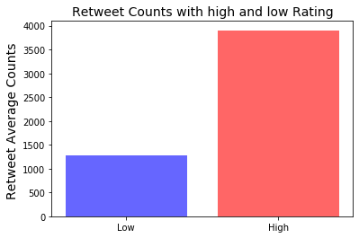

```python
locations = [1, 2]
heights = [low_retweets, high_retweets]
labels = ['Low', 'High']
plt.bar(locations, heights, tick_label=labels , color=['blue' , 'red'] , alpha= 0.6)
plt.ylabel('Retweet Average Counts ', fontsize=14);
plt.title('Retweet Counts with high and low Rating', fontsize=14);
```

*Huge difference but I think it's realistic.*